# TND Asx

Edgar Ortiz Brizuela

2023-01-31

# Packages

Install/load the necessary packages for this code.

```r
if (!require(pacman)) {
  install.packages("pacman")}
```

```r
p_load(ggdag,
       tidyverse,
       xtable,
       plotly,
       grid,
       gridExtra,
       ggpubr,
       htmlwidgets)
```

# *****************************

# *****************************

This section is aimed at generating the DAGs described in the manuscript.

## DAG 1: Data generating structure

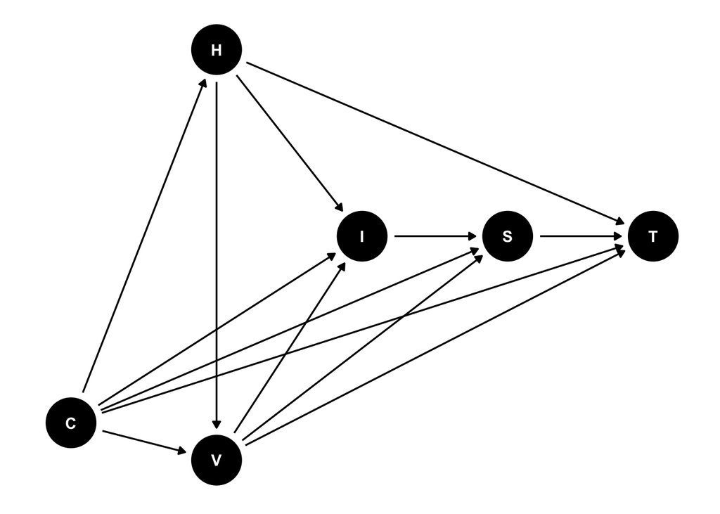

```r
# 1. Create a DAG object with dagify

Dag1 =
  ggdag::dagify(
    V ~ H + C,
    I ~ H + V + C,
    S ~ I + V + C,
    T ~ S + H + C + V,
    H ~ C,
    exposure = "V",
    outcome = c("I"),
    coords = list(y = c(V = -5,
                        I = 1,
                        S = 1,
                        T = 1,
                        H = 6,
                        C = -4),
                  x = c(V = 3,
                        I = 4,
                        S = 5,
                        T = 6,
                        H = 3,
                        C = 2)
                  ))


# 2. Plot

DagDataGeneratingStructure =
Dag1 %>%
  ggdag() +
  theme_dag() +
  theme(
    panel.background = element_blank(),
    plot.background = element_blank()
    )


# 3. Save the plot as a PNG file

ggsave(
  filename = "Dag1.png",
  plot = DagDataGeneratingStructure,
  width = 7,    # width in inches
  height = 4,    # height in inches
  dpi = 300,     # resolution (dots per inch)
  bg = "transparent"
)

DagDataGeneratingStructure
```

## DAG 2. Classical

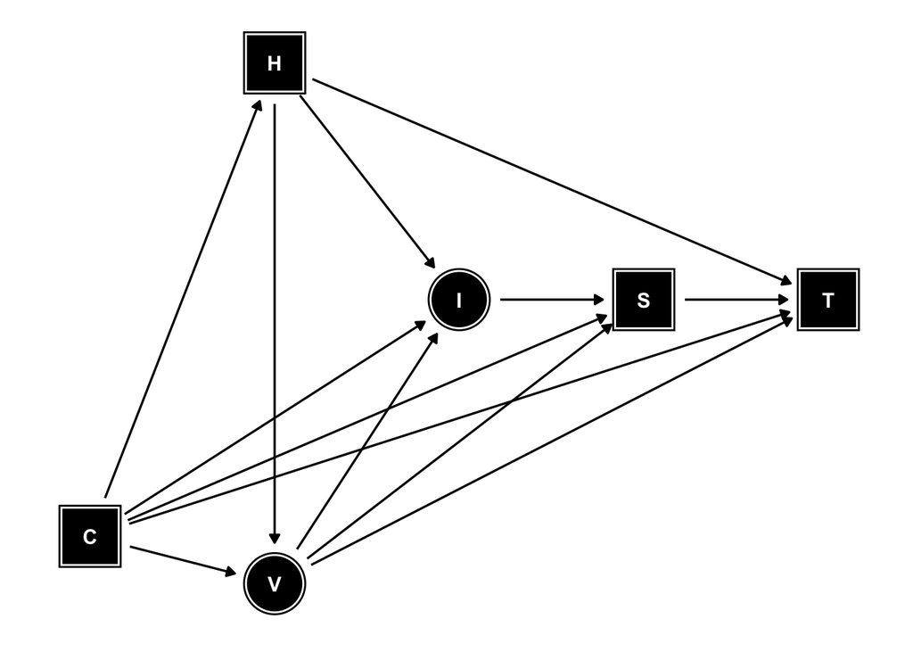

```r
# 1. Create a DAG for the classical TND

DagClassical <- Dag1 %>%
  node_dconnected("V",
                  c("I","S"),
                  controlling_for = c("C", "H", "S", "T")) %>%
  ggplot(aes(x = x,
             y = y,
             xend = xend,
             yend = yend,
             shape = adjusted)) +
  geom_dag_edges() +
  geom_dag_node() +
  geom_dag_text(col = "white") +
  theme_dag() +
  #labs(shape = "Adjustment") +
  scale_shape_manual(values = c(15, 16),
                     # labels = c("Adjusted", "Unadjusted"),
                     guide = "none") +
  theme(
    panel.background = element_blank(),
    plot.background = element_blank()
  )


# 2. Save the plot as a PNG file

ggsave(
  filename = "DagClassical.png",
  plot = DagClassical,
  width = 7,    # width in inches
  height = 4,    # height in inches
  dpi = 300,     # resolution (dots per inch)
  bg = "transparent"
)

DagClassical
```

*Extra:*

Identify open paths (using ggdag functions)

```r
# Identify open paths

Dag1 %>%
  ggdag_paths(from = "V",
                  to = "I",
                  adjust_for = c("C", "H", "S", "T"),
              shadow = T) +
  theme_dag()
```

## DAG 3: Alternative

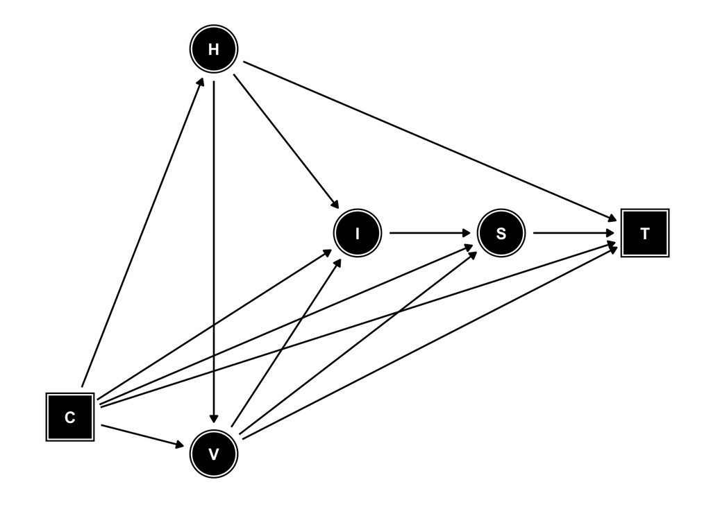

```r
# 1. Create a DAG for the alternative TND

DagAlternative <- Dag1 %>%
  node_dconnected("V", c("I"),
                  controlling_for = c("C", "T")) %>%
  ggplot(aes(x = x,
             y = y,
             xend = xend,
             yend = yend,
             shape = adjusted)) +
  geom_dag_edges() +
  geom_dag_node() +
  geom_dag_text(col = "white") +
  theme_dag() +
  scale_adjusted() +
  #labs(shape = "Adjustment") +
  scale_shape_manual(values = c(15, 16),
                     #labels = c("Adjusted", "Unadjusted"),
                     guide = "none") +
  theme(
    panel.background = element_blank(),
    plot.background = element_blank()
  )


# 2. Save the plot as a PNG file
ggsave(
  filename = "DagAlternative.png",
  plot = DagAlternative,
  width = 7,    # width in inches
  height = 4,    # height in inches
  dpi = 300,     # resolution (dots per inch)
  bg = "transparent"
)

DagAlternative
```

*Extra:* Identify open paths.

```r
# Identify open paths

Dag1 %>%
  ggdag_paths(from = "V",
                  to = "I",
                  adjust_for = c("C", "T"),
              shadow = T) +
  theme_dag()
```

## DAG 4: Misclassification

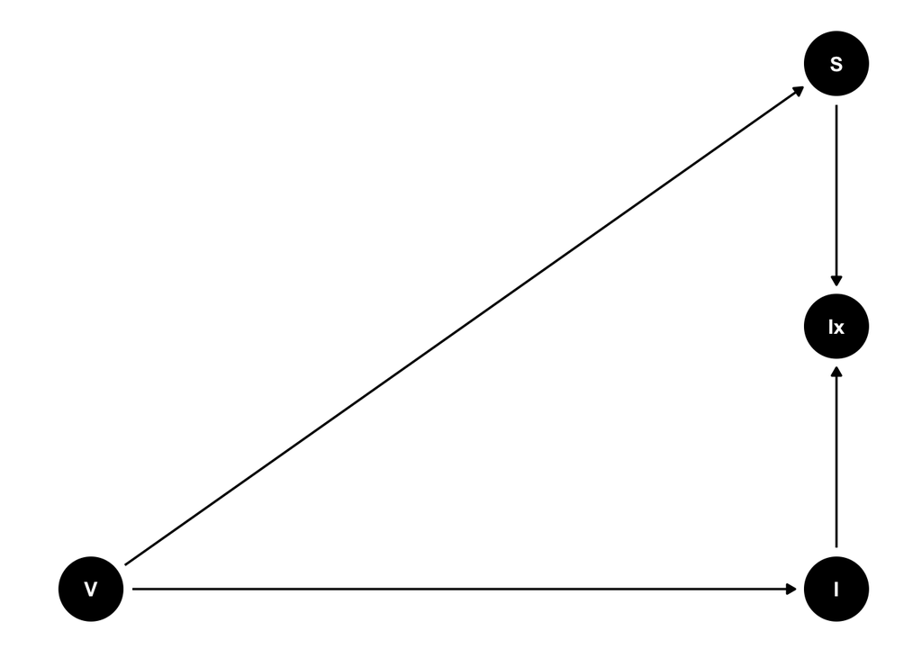

```r
# 1. Create a DAG to represent misclassification in alternative TND studies

MCDag = ggdag::dagify(
    S ~ V,
    Ix ~ S + I,
    I  ~ V,
    exposure = "V",
    outcome = c("I"),
    coords = list(y = c(V = 0,
                        I = 0,
                        Ix = 1,
                        S = 2),
                  x = c(V = 0,
                        I = 1.5,
                        S = 1.5,
                        Ix = 1.5)
    ))


# 2. Plot

DagMC =
MCDag %>%
  ggdag() +
  theme_dag() +
  theme(
    panel.background = element_blank(),
    plot.background = element_blank()
  )


# 3. Save the plot as a PNG file

ggsave(
  filename = "DagMC.png",
  plot = DagMC,
  width = 4,    # width in inches
  height = 4,    # height in inches
  dpi = 300,     # resolution (dots per inch)
  bg = "transparent"
)

DagMC
```

## DAG 5: T_select

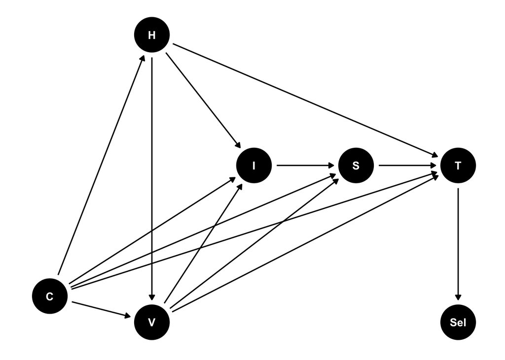

```r
# 1. DAG object

Dag_T_select =
  ggdag::dagify(
    V ~ H + C,
    I ~ H + V + C,
    S ~ I + V + C,
    T ~ S + H + C + V,
    H ~ C,
    Sel ~ T,
    exposure = "V",
    outcome = c("S"),
    coords = list(y = c(V = -5,
                        I = 1,
                        S = 1,
                        T = 1,
                        H = 6,
                        C = -4,
                        Sel = -5),
                  x = c(V = 3,
                        I = 4,
                        S = 5,
                        T = 6,
                        H = 3,
                        C = 2,
                        Sel = 6)
                  ))


# 2. Plot

DAG_T_select =
Dag_T_select %>%
  ggdag() +
  theme_dag() +
  theme(
    panel.background = element_blank(),
    plot.background = element_blank()
    )


# 3. Save the plot as a PNG file

ggsave(
  filename = "DAG_T_select.png",
  plot = DAG_T_select,
  width = 7,    # width in inches
  height = 4,    # height in inches
  dpi = 300,     # resolution (dots per inch)
  bg = "transparent"
)

DAG_T_select
```

## DAGs merged

Save the four DAGs in a single plot.

### 4 dags

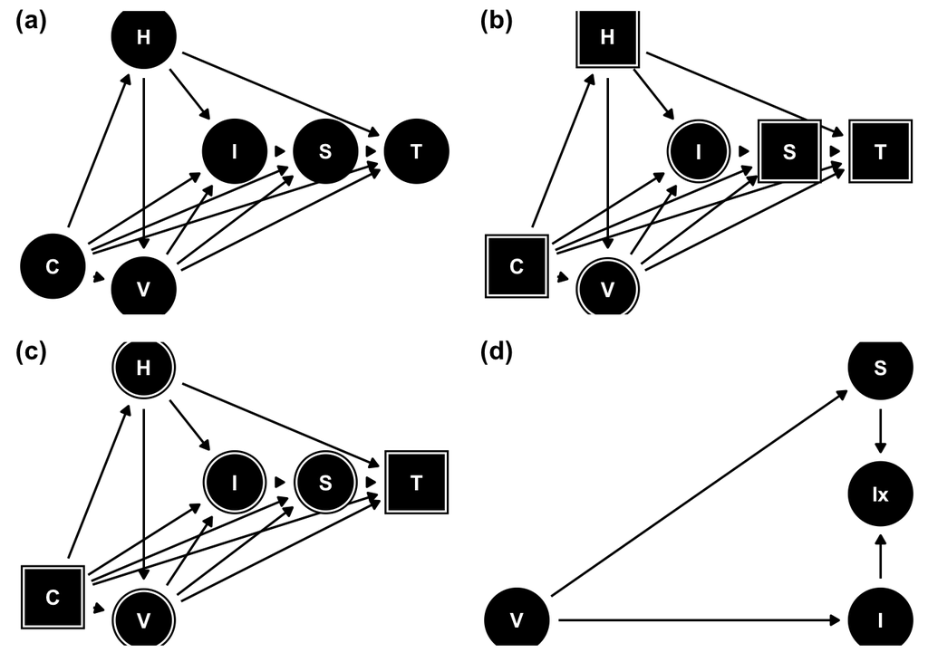

```r
# 1. Modify the plot names

plot1 = DagDataGeneratingStructure
plot2 = DagClassical
plot3 = DagAlternative
plot4 = DagMC


# 2. Combine the plots into one plot

combined_plot <-
  ggpubr::ggarrange(plot1,
                    plot2,
                    plot3,
                    plot4,
                    nrow = 2,
                    ncol = 2,
                    labels = c("(a)", "(b)", "(c)", "(d)"),
                    widths = c(1, 1),
                    heights = c(1, 1))

# Save the combined plot as a JPEG

# 2. Save the plot as a PNG file

ggsave(
  filename = "Combined_DAGs.png",
  plot = combined_plot,
  width = 12,    # width in inches
  height = 7,    # height in inches
  dpi = 300,     # resolution (dots per inch)
  bg = "transparent"
)

# Print DAG

combined_plot
```

### 3 dags

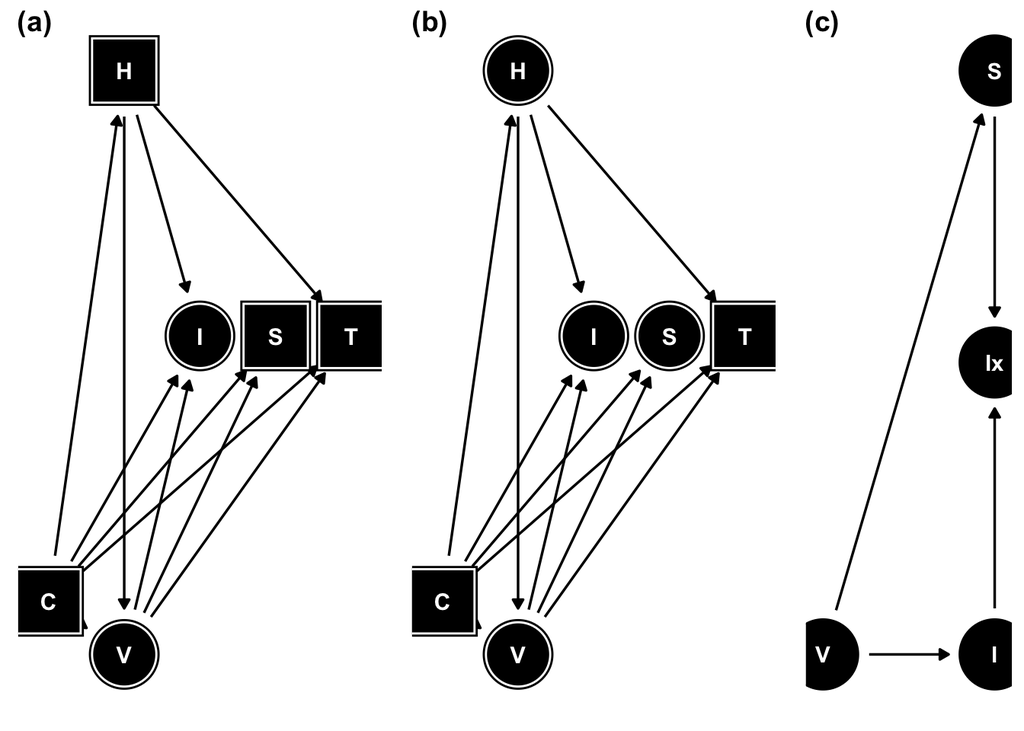

```r
# 1. Modify the plot names

plot2 = DagClassical
plot3 = DagAlternative
plot4 = DagMC


# 2. Combine the plots into one plot

combined_plot <-
  ggpubr::ggarrange(plot2,
                    plot3,
                    plot4,
                    nrow = 1,
                    ncol = 3,
                    labels = c("(a)", "(b)", "(c)"),
                    widths = c(1, 1, 0.6),
                    heights = c(1, 1, 1))

# Save the combined plot as a JPEG

# 2. Save the plot as a PNG file

ggsave(
  filename = "Combined_DAGs_3.png",
  plot = combined_plot,
  width = 14,    # width in inches
  height = 3.5,    # height in inches
  dpi = 300,     # resolution (dots per inch)
  bg = "transparent"
)

# Print DAG

combined_plot
```

# *****************************

# *****************************

Hereafter, we will conduct the simulation study, which is divided into three sections. In Section 1 (i.e., “SIMS 1”), we carry out the main simulation study and vary each of the parameters individually. In Section 2 (i.e., “SIMS 2”), we vary two or more parameters simultaneously. Finally, in Section 3 (i.e., “SIMS 3”), we assess the potential impact of differential misclassification of outcome status in “alternative” TND studies.

# —————————————————————————–

# SIMS 1: uncontrolled confounding & collider bias (a) ————————

# —————————————————————————–

## 1) Seeds file

Here we generate a text file that contains a series of seeds to ensure the replicability of results.

```r
# 1. Set a seed to generate the seeds file.

set.seed(123)

# 2. Generate the seeds file

write(sample(1:10000000,
             size=10000),
      file="seeds.txt",
      ncolumns=1)

# 3. Read the seeds file and store its contents in an R object.

seeds<-read.table("seeds.txt",
                  header=F)$V1
```

## 2) “datagen” function

Here we create a function to simulate the DAG depicted in Figure 1.

*Note*: the “cf” and “mc” arguments are switches that enable the generation of “counterfactual” dfs and a variable representing measured infection status, respectively.

```r
# 1) Create a data-generation function:

datagen = function(cf = F, # cf = counterfactual
                   mc = F, # mc = misclassification
                   popsize = 1000000,
                   seed = 123,
                   OR_HV = 1.81, # beta 2
                   OR_HI = 0.9,  # gamma 1,2 and gamma 2,2
                   OR_IS = 10, # delta 4 and delta 5
                   OR_IVS = 0.52, # delta 6
                   OR_HT = 1.3, # theta 2
                   OR_VT = 0.92, # theta 3
                   OR_ST = 6, # theta 4
                   T_Intercept = -38.8, # theta 0
                   I2_Intercept = -5.4 # gamma 2,0
                   ){

  set.seed(seed) # Set seed

  ID = tibble(id = 1:popsize) # Create n=popsize consecutive "IDs"

  df = ID %>% # Generate nodes (Start) ----------------------------------------

  mutate(

      C = rnorm(mean = 40,
                sd = 4,
                n = n()),

      H = rbinom(n=n(),
                 size=1,
                 prob = plogis(-19.4 + # alpha 0
                                 log(1.59)*C)), # alpha 1

      V = rbinom(n=n(),
                 size=1,
                 prob = plogis(-12.25 + # beta 0
                                 log(1.36)*C + # beta 1
                                 log(OR_HV)*H)), # beta 2

      I1 = rbinom(n=n(),
                  size=1,
                  prob = plogis(-6.7 + # gamma 1,0
                                  log(1.12)*C + # gamma 1,1
                                  log(OR_HI)*H)), # gamma 1,2

      I2 = rbinom(n=n(),
                  size=1,
                  prob = plogis(I2_Intercept + # gamma 2,0
                                  log(1.12)*C + # gamma 2,1
                                  log(OR_HI)*H + # gamma 2,2
                                  log(0.1)*V))* # gamma 2,3
           (1-I1),

      S = rbinom(n=n(),
                 size = 1,
                 prob = plogis(-33.8 + # delta 0
                                 log(1.2)*C + # delta 1
                                 log(1.93)*C*I1 + # delta 2
                                 log(1.93)*C*I2 +  # delta 3
                                 log(OR_IS)*I1 + # delta 4
                                 log(OR_IS)*I2 + # delta 5
                                 log(OR_IVS)*I2*V))* # delta 6
           (I1+I2),


      H0S1 = ifelse(H==0 & S==1, # dummy variable for T
                    1,0),

      H1S1 = ifelse(H==1 & S==1,  # dummy variable for T
                    1,0),

      T = rbinom(n=n(),
                 size = 1,
                 prob = plogis(T_Intercept + # theta 0
                                 log(2.47)*C + # theta 1
                                 log(OR_HT)*H + # theta 2
                                 log(OR_VT)*V + # theta 3
                                 log(OR_ST)*S)) * # theta 4
           (1 - H1S1) * (1 - H0S1) + H1S1

    ) # Mutate (End) --------------------------------------------------------

    # Counterfactuals (Start) -----------------------------------------------

    if(cf == T) { # cf stands for counterfactual (this is a "switch")

      df = df %>% mutate(

        # I2 Had everyone been vaccinated ************************************

        I21 = rbinom(n=n(),
                    size=1,
                    prob = plogis(I2_Intercept + # gamma 2,0
                                    log(1.12)*C + # gamma 2,1
                                    log(OR_HI)*H + # gamma 2,2
                                    log(0.1)*1))* # # gamma 2,3; replaced V by 1
              (1-I1),


        # I2 Had no one been vaccinated **************************************

        I20 = rbinom(n=n(),
                    size=1,
                    prob = plogis(I2_Intercept + # gamma 2,0
                                    log(1.12)*C + # gamma 2,1
                                    log(OR_HI)*H + # gamma 2,2
                                    log(0.1)*0))* # # gamma 2,3; replaced V by 0
              (1-I1),


        # S Had everyone been vaccinated *************************************

        S1 = rbinom(n=n(),
                   size = 1,
                   prob = plogis(-33.8 + # delta 0
                                   log(1.2)*C + # delta 1
                                   log(1.93)*C*I1 + # delta 2
                                   log(1.93)*C*I21 +  # delta 3; replace I2->I21
                                   log(OR_IS)*I1 + # delta 4;
                                   log(OR_IS)*I21 + # delta 5; replace I2->I21
                                   log(OR_IVS)*I21*1))* # d6; re. I2->I21 & V->1
             (I1+I21), # replace I2 by I21


        # S Had no one been vaccinated ****************************************

        S0 = rbinom(n=n(),
                   size = 1,
                   prob = plogis(-33.8 + # delta 0
                                   log(1.2)*C + # delta 1
                                   log(1.93)*C*I1 + # delta 2
                                   log(1.93)*C*I20 + # delta 3; repl. I2->I20
                                   log(OR_IS)*I1 + # delta 4
                                   log(OR_IS)*I20 + # delta 5; repl. I2->I20
                                   log(OR_IVS)*I20*0))* # d6; I2->I20 and V->0
             (I1+I20), # Replace I2 by I20



        # T Had everyone been vaccinated **************************************

        H0S1_1 = ifelse(H==0 & S1==1, # replace S by S1
                        1,0),

        H1S1_1 = ifelse(H==1 & S1==1, # replace S by S1
                        1,0),


        T1 = rbinom(n=n(),
                 size = 1,
                 prob = plogis(T_Intercept + # theta 0
                                 log(2.47)*C + # theta 1
                                 log(OR_HT)*H + # theta 2
                                 log(OR_VT)*1 + # theta 3 - replaced by 1
                                 log(OR_ST)*S1)) * # theta 4 - reblaced by S1
           (1 - H1S1_1) * (1 - H0S1_1) + H1S1_1, # replace H0S1 and H1S1


        # T had no one been vaccinated ****************************************

        H0S1_0 = ifelse(H==0 & S0==1, # replace S by S0
                        1,0),

        H1S1_0 = ifelse(H==1 & S0==1, # replace S by S0
                        1,0),


        T0 = rbinom(n=n(),
                 size = 1,
                 prob = plogis(T_Intercept + # theta 0
                                 log(2.47)*C + # theta 1
                                 log(OR_HT)*H + # theta 2
                                 log(OR_VT)*0 + # theta 3 - replaced by 0
                                 log(OR_ST)*S0)) * # theta 4 - reblaced by S0
           (1 - H1S1_0) * (1 - H0S1_0) + H1S1_0



       ) # Mutate end.

    } # Counterfactuals (End) -------------------------------------------------

  if(mc == T) { # "mc" stands for misclassification (this is a "switch")

    df = df %>%
      mutate( # Mutate start

        I2_star =
          ifelse(S==1 & I2==1,
                 rbinom(n = n(),
                        size = 1,
                        prob = 0.971), # Sens in S=1
                 ifelse(S==0 & I2==1,
                        rbinom(n = n(),
                               size = 1,
                               prob = 0.581), # Sens in S=0
                        rbinom(n=n(),
                               size = 1,
                               prob = (1-0.989)))) # Spec. complement for all

            ) # Mutate end

  } # "mc" (End)

  return(df)

}
```

## 3) True value for Target Parameters

To obtain the target parameters, we simulate two counterfactual scenarios: one where everyone is vaccinated, and another where no one is vaccinated. We perform these simulations on a very large synthetic population (i.e., n = 100,000,000).

Note: In our simulation, since there is no effect measure modification by C, the conditional RR for either symptomatic infection or infection regardless of symptoms simplifies to the marginal RR for symptomatic infection and infection, respectively. Empirical proof of this is provided in step 5-i below.

```r
A=Sys.time() # to measure elapsed time

# 1. Generate the counterfactual data and save it as "counterfactual"

counterfactual = datagen(cf = T,
                         popsize = 100000000, # 100,000,000
                         seed = 123)


# 2. Gen. a variable that stands for S:I:T had everyone been vaccinated (Y1)

counterfactual$Y1 = counterfactual$S1*counterfactual$I21*counterfactual$T1

# 3. Gen. a variable that stands for S:I:T had no one been vaccinated (Y0)

counterfactual$Y0 = counterfactual$S0*counterfactual$I20*counterfactual$T0

# 4. Get the marginal causal RR vs infection (for the alternative TND)

(Cf_Marginal_RR_Vs_I =
    mean(counterfactual$I21)/
    mean(counterfactual$I20))
```

```
## [1] 0.1416598
```

```r
# 5. # 4. Get the marginal causal RR vs symptomatic infection (classical TND)

(Cf_Marginal_RR_Vs_SI =
    mean(counterfactual$Y1)/
    mean(counterfactual$Y0))
```

```
## [1] 0.1486391
```

```r
# 6. Measure elapsed time

rm(counterfactual)

B=Sys.time(); (B-A)
```

```
## Time difference of 1.146053 mins
```

## 4) Sim. scenario wo/MC and w/best guesses

### a. For loop

Here, we use the function created above to conduct 1000 Monte Carlo simulations, followed by estimation of bias using the true RR estimates.

```r
#------------------------------------------------------------------------------
#------------------ GET EVERYTHING READY FOR THE FOR LOOP  --------------------
#------------------------------------------------------------------------------

# 1) Save starting time

(A=Sys.time())
```

```
## [1] "2023-10-12 00:46:38 CST"
```

```r
# 2) Define the number of simsulations and create an empty df to store results

## Number of simulations
nsims = 1000

## Empty df
results = data.frame(matrix(ncol = 5,
                            nrow = nsims))

colnames(results) = c("iteration",
                      "VE_Classical",
                      "SE_Classical",
                      "VE_Alternative",
                      "SE_Alternative")

# 3) Set popsize for each simulation
popsize = 1000000 # 1,000,000


#------------------------------------------------------------------------------
#--------------------------- START SIMULATIONS  -------------------------------
#------------------------------------------------------------------------------

  for (i in 1:nsims){

  # a. Simulate i-th data-frame -----------------------------------------------

  df = datagen(cf = F,
               popsize = popsize,
               seed = seeds[i])

  # b. Select the "classical" & "alternative" populations from the i-th df ----

  df_classical = df %>% # classical: symptomatic & tested individuals
    filter(T==1 &  S==1)

  df_alternative = df %>%
    filter(T==1)  # alternative: all tested individuals


  # c. Get log(OR)s estimates and their SEs -----------------------------------

  ## Classical TND

  fit.classical<-glm(I2~V+C,
                       family = binomial,
                       data = df_classical)

  results.classical = summary(fit.classical)

  ## Alternative TND

  fit.alternative<-glm(I2~V+C,
                         family = binomial,
                         data = df_alternative)

  results.alternative = summary(fit.alternative)


  # d. Save results -----------------------------------------------------------

  ## Iteration number
  results[i,1] = i
  ## VE against S:I (log[OR])
  results[i,2] = results.classical$coefficients[2]
  ## SE of VE against S:I
  results[i,3] = results.classical$coefficients[5]
  ## VE against I (log[OR])
  results[i,4] = results.alternative$coefficients[2]
  ## SE of VE against I
  results[i,5] = results.alternative$coefficients[5]

  }


# Measure the elapsed time

(B=Sys.time()); B-A
```

```
## [1] "2023-10-12 00:57:13 CST"
```

```
## Time difference of 10.57421 mins
```

```r
# Store results

main.results.original = results
```

### b. Analyze results

We will now analyze the results of the main simulation.

```r
# 1) Classical TND  -----------------------------------------------------------

## RR vs SI

round(Cf_Marginal_RR_Vs_SI, 3)
```

```
## [1] 0.149
```

```r
## mean OR vs SI
measured.conditional.OR.SI =
  mean(main.results.original$VE_Classical, na.rm = T)
round(exp(measured.conditional.OR.SI), 3)
```

```
## [1] 0.141
```

```r
## Avg SE Classical

Main_Results.Avg_SE_Classical =
  sqrt(mean(main.results.original$SE_Classical^2, na.rm = T))
round(Main_Results.Avg_SE_Classical, 3)
```

```
## [1] 0.019
```

```r
## MC SE Classical

Main_Results.MCSE_Classical =
  sd(main.results.original$VE_Classical, na.rm = T)
round(Main_Results.MCSE_Classical,3)
```

```
## [1] 0.019
```

```r
## Bias of the OR vs SI

round(
  exp(measured.conditional.OR.SI) - # i.e., exp(mean(betas))
  Cf_Marginal_RR_Vs_SI, 3) # i.e., ((marginalRR))
```

```
## [1] -0.008
```

```r
# 2) Alternative TND  ---------------------------------------------------------

## RR vs I

round(Cf_Marginal_RR_Vs_I, 3)
```

```
## [1] 0.142
```

```r
## mean OR vs I

measured.conditional.OR.I =
  mean(main.results.original$VE_Alternative, na.rm = T)
round(exp(measured.conditional.OR.I), 3)
```

```
## [1] 0.125
```

```r
## Avg SE Alternative

Main_Results.Avg_SE_Alternative =
  sqrt(mean(main.results.original$SE_Alternative^2, na.rm = T))
round(Main_Results.Avg_SE_Alternative, 3)
```

```
## [1] 0.014
```

```r
## MC SE Alternative

Main_Results.MCSE_Alternative =
  sd(main.results.original$VE_Alternative, na.rm = T)
round(Main_Results.MCSE_Alternative, 3)
```

```
## [1] 0.014
```

```r
## Bias of the OR vs I

round(
  exp(measured.conditional.OR.I) - # i.e., exp(mean(betas))
  Cf_Marginal_RR_Vs_I, 3) # i.e., ((marginalRR))
```

```
## [1] -0.016
```

## 5) Vary parameters

### a. “vary_parameters” function

To assess the robustness of our conclusions, we will vary the selected parameters. We have developed a function that follows a four-step process:

1. Create a data frame to store the results of all the preceding steps (i.e., steps 2-4 above) but with the altered parameter (e.g., OR HV = x).
2. Create an empty list to store the results for each varied value of the “x” parameter (e.g., OR HV).

3-4) Execute a for loop for each chosen parameter and save the results in a list.

Thus, the final output is a list containing ‘n’ data frames (with ‘n’ equal to the number of chosen values for each varied parameter) with the log(OR) and its SE estimates. Moreover, in each data frame, each row corresponds to the results after analyzing a simulated dataframe, each of them with a different seed, but with the same value for the varied parameter for that dataframe.

```r
#----------------------------------------------------------------------------
#------------------------  vary_parameters FUNCTION  ------------------------
#----------------------------------------------------------------------------

vary_parameters <- function(parametros = NULL, # Vector w/params. to be varied
                            nsims = 1000, # number of simulations per parameter
                            popsize = 1000000, # population size
                            seeds = NULL, # df with seeds
                            argument = NULL # parameter to vary e.g., "OR_HV ="
                            ){ # FUNCTION START


  # 1) Create an empty df to store VE results ---------------------------------

  results = data.frame(matrix(ncol = 6, nrow = nsims)) # empty df
  colnames(results) = c("iteration", # column names
                        "VE_Classical",
                        "SE_Classical",
                        "VE_Alternative",
                        "SE_Alternative",
                        "Formula") # to save the param. changed as quality ctrl

  # 2) Create an empty list to store results for each iteration ---------------

  lista = list()

  # 3) For loop 1: Iterate over j-th parameters in parametros set -------------

  for (j in 1:length(parametros)){ # Start of "loop 1"

  ## 3a) Pick the j-th parameter from the parametros set, then, paste the ...
  ### picked value to its argument (the parameter changed, e.g., "OR_HV"), ...
  ### finally transform it into R object to be used as argument within datagen:

  parametro = parametros[j]
  formula = paste(argument, parametro)

  ## 3b) Get VE and SE from n (n=nsims) simulations using the picked parameter:

  for (i in 1:nsims){ # Start of "loop 2".

  ### i. generate data
  df =
    eval(
      parse(
        text = paste(
          "datagen(cf=F, popsize=popsize, seed = seeds[i],",
          formula,
          ")" )))

  ### ii. select study populations for both designs

  df_classical = df %>% filter(T==1 & S==1)
  df_alternative = df %>% filter(T==1)


  ### iii. get VE estimates and their SEs

  #### Classical TND

  fit.classical<-glm(I2~V+C,
                       family = binomial,
                       data = df_classical)
  results.classical = summary(fit.classical)

  #### Alternative TND

  fit.alternative<-glm(I2~V+C,
                         family = binomial,
                         data = df_alternative)
  results.alternative = summary(fit.alternative)


  ### iv. Save results

  #### Iteration number
  results[i,1] = i
  #### VE against S:I (log OR)
  results[i,2] = results.classical$coefficients[2]
  #### SE of VE against S:I
  results[i,3] = results.classical$coefficients[5]
  #### VE against I  (log OR)
  results[i,4] = results.alternative$coefficients[2]
  #### SE of VE against I
  results[i,5] = results.alternative$coefficients[5]
  #### Parameter
  results[i,6] = formula

    } # End of "loop 2"

  ### v. Store df of results in a list

  lista[[j]] = results
  print(j)


  } # End of "loop 1" ---------------------------------------------------------


  # 4) Return results ---------------------------------------------------------

    return(lista)

} # FUNCTION END
```

### b. “get_cfs” function

This function computes the counterfactual VE, incorporating the new parameters, in this case using 10,000,000 instead of 100,000,000 due to computational constraints, and stores it in a new list. This is primarily because changing the original parameters also changes the “true” VE.

```r
#----------------------------------------------------------------------------
#------------------------  get_cfs FUNCTION  --------------------------------
#----------------------------------------------------------------------------

get_cfs <- function(parametros = NULL, # Vector w/parameters to be varied
                    popsize = 10000000, # population size
                    argument = NULL # e.g., "OR_HV =", parameter to vary
                    ) { # FUNCTION START


  # 1. Create empty list to store the new true VE for each parameter

  lista = list()

  # 2. Use a for loop to iterate over n values of the chosen parameter

  for(i in 1:length(parametros)){

  parametro = parametros[i]
  formula = paste(argument, parametro)

  df.sec =
    eval(
      parse(
        text = paste(
          "datagen(cf=T, popsize=popsize,", formula, ")")))


  df.sec$Y1 = df.sec$S1*df.sec$I21*df.sec$T1 # Y^a=1
  df.sec$Y0 = df.sec$S0*df.sec$I20*df.sec$T0 # Y^a=0


  # Get the true VE vs symptomatic infection
  Cf_Marginal_RR_Vs_SI.Sec = mean(df.sec$Y1)/mean(df.sec$Y0)

  # Get the true VE vs infection
  Cf_Marginal_RR_Vs_I.Sec = mean(df.sec$I21)/mean(df.sec$I20)


  lista[[i]] = c(Cf_Marginal_RR_Vs_SI.Sec,
                 Cf_Marginal_RR_Vs_I.Sec)
  print(formula)

}

  return(lista)

}
```

### c. Sims. w/varied params. wo/MC

The process of iterating over the parameter sets involves two steps:

1. We run the function “vary_parameters” once for each value selected for the parameter that is varied, in order to obtain the measured VE for each iteration. Results are stored in a list of data frames (hereafter, *list one*; each dataframe contains 1000 rows, each row with one iteration of the simulation with the selected value for the parameter that is being varied, therefore, the list contains 10 dataframes, each of them corresponding to 10 different values of the parameter selected).
2. Using a for loop, the counterfactual VE is computed again—this time using 10,000,000 instead of 100,000,000 due to computational constraints—and stored in a new list (hereafter, *list two*). This is primarily for the parameters early in the simulation since this changes the true VE.

#### i. OR HV

```r
# Register starting time
(A=Sys.time()) # to measure elapsed time
```

```
## [1] "2023-10-12 00:57:13 CST"
```

```r
## ---------- Step 1 - iterate over OR_HV ------------------------------------- # <----------- Update

parametros.OR_HV = c(seq(from = 1.5, to = 10.5, by = 1)) # <----------- Update
parametros = parametros.OR_HV # <--------------------------------------- Update
argument = "OR_HV =" # <------------------------------------------------ Update

lista_resultados.OR_HV = # <--------------------------------------- Update
  vary_parameters(
    parametros = parametros,
    nsims = 1000,
    popsize = 1000000,
    seeds = seeds,
    argument = argument)
```

```
## [1] 1
## [1] 2
## [1] 3
## [1] 4
## [1] 5
## [1] 6
## [1] 7
## [1] 8
## [1] 9
## [1] 10
```

```r
## ----------- Step 2 - get Cf for OR_HV -------------------------------------- <----------- Update

lista_Cf.OR_HV =  # <--------------------------------------------------- Update
  get_cfs(parametros = parametros,
          popsize = 10000000,
          argument = argument)
```

```
## [1] "OR_HV = 1.5"
## [1] "OR_HV = 2.5"
## [1] "OR_HV = 3.5"
## [1] "OR_HV = 4.5"
## [1] "OR_HV = 5.5"
## [1] "OR_HV = 6.5"
## [1] "OR_HV = 7.5"
## [1] "OR_HV = 8.5"
## [1] "OR_HV = 9.5"
## [1] "OR_HV = 10.5"
```

```r
B=Sys.time(); (B-A)
```

```
## Time difference of 1.6238 hours
```

Extra: The following ‘for loop’ demonstrates that in our simulation, the marginal RR simplifies to the conditional RR, even when varying the parameters. This is also explained in the following reference:

DOI: 10.1177/0962280213502146

```r
A=Sys.time()

# 1. Create an empty list to store the new true VE for each parameter
lista = list()

# 2. Select the values for the target parameter to test
parametros = parametros.I2_Intercept_v2

# 3. Run a for loop but change manually the parameter below
for(i in 1:length(parametros)){

    parametro = parametros[[i]]

    df.sec = datagen(cf=T,
                     popsize = 10000000,
                     I2_Intercept = parametro) # <-- 3.1 Change manually the param.

    df.sec$Y1 = df.sec$S1*df.sec$I21*df.sec$T1 # Y^a=1
    df.sec$Y0 = df.sec$S0*df.sec$I20*df.sec$T0 # Y^a=0

    ## 3.2 Create a new data frame 'ds.c' containing the counterfactual pops.
    ds.c = data.frame(Y = c(df.sec$Y1, df.sec$Y0), # stacked cf outcomes
                  A = rep(c(1,0), each = 10000000), # stacked cf exposures
                  C = c(df.sec$C, df.sec$C), # stacked cf levels of C
                  H = c(df.sec$H, df.sec$H), # stacked cf levels of H
                  I = c(df.sec$I21, df.sec$I20)) # stacked cf levels of I2

    ## 3.3 Get the true conditional VE vs symptomatic infection
    mod1 = glm(Y ~ A + C + H, family = poisson(link = "log"), data = ds.c)

    ## 3.4 Get the true conditional VE vs infection
    mod1b = glm(I ~ A + C + H, family = poisson(link = "log"), data = ds.c)

    ## 3.5 Store the results
    ### Counterfactual conditional RR vs SI
    (Cf_Marginal_RR_Vs_SI.Sec = exp(coef(mod1)[2]))

    ### Counterfactual conditional RR vs I
    (Cf_Marginal_RR_Vs_I.Sec = exp(coef(mod1b)[2]))

    ### Save a list
    lista[[i]] = c(Cf_Marginal_RR_Vs_SI.Sec,
                   Cf_Marginal_RR_Vs_I.Sec)

}

lista.Cf.prueba = lista

B=Sys.time(); (B-A)

# Compare the results

list1=lista.Cf.prueba
list2=rev(lista_Cf.I2_Intercept) # <----------------------------------- Update


result <- Map(function(x, y) round(x - y, 6), list1, list2)
print(result)
```

#### ii. OR HI

```r
# 1. Register starting time
(A=Sys.time()) # to measure elapsed time
```

```
## [1] "2023-10-12 02:34:39 CST"
```

```r
# 2. Run functions

## ---------- Step 1 - iterate over OR_HI -------------------------------------

parametros.OR_HI = c(seq(from = 0.05, to = 0.95, by = 0.1))
parametros = parametros.OR_HI
argument = "OR_HI ="

lista_resultados.OR_HI =
  vary_parameters(
    parametros = parametros,
    nsims = 1000,
    popsize = 1000000,
    seeds = seeds,
    argument = argument)
```

```
## [1] 1
## [1] 2
## [1] 3
## [1] 4
## [1] 5
## [1] 6
## [1] 7
## [1] 8
## [1] 9
## [1] 10
```

```r
## ----------- Step 2 - get Cf for OR_HI --------------------------------------

lista_Cf.OR_HI =
  get_cfs(parametros = parametros,
          popsize = 10000000,
          argument = argument)
```

```
## [1] "OR_HI = 0.05"
## [1] "OR_HI = 0.15"
## [1] "OR_HI = 0.25"
## [1] "OR_HI = 0.35"
## [1] "OR_HI = 0.45"
## [1] "OR_HI = 0.55"
## [1] "OR_HI = 0.65"
## [1] "OR_HI = 0.75"
## [1] "OR_HI = 0.85"
## [1] "OR_HI = 0.95"
```

```r
B=Sys.time(); (B-A)
```

```
## Time difference of 1.635991 hours
```

#### iii. OR IS

```r
# Register starting time
(A=Sys.time()) # to measure elapsed time
```

```
## [1] "2023-10-12 04:12:48 CST"
```

```r
## ---------- Step 1 - iterate over OR_IS -------------------------------------

parametros.OR_IS = c(seq(from = 1.5, to = 10.5, by = 1))
parametros = parametros.OR_IS
argument = "OR_IS ="

lista_resultados.OR_IS =
  vary_parameters(
    parametros = parametros,
    nsims = 1000,
    popsize = 1000000,
    seeds = seeds,
    argument = argument)
```

```
## [1] 1
## [1] 2
## [1] 3
## [1] 4
## [1] 5
## [1] 6
## [1] 7
## [1] 8
## [1] 9
## [1] 10
```

```r
## ----------- Step 2 - get Cf for OR_IS --------------------------------------

lista_Cf.OR_IS =
  get_cfs(parametros = parametros,
          popsize = 10000000,
          argument = argument)
```

```
## [1] "OR_IS = 1.5"
## [1] "OR_IS = 2.5"
## [1] "OR_IS = 3.5"
## [1] "OR_IS = 4.5"
## [1] "OR_IS = 5.5"
## [1] "OR_IS = 6.5"
## [1] "OR_IS = 7.5"
## [1] "OR_IS = 8.5"
## [1] "OR_IS = 9.5"
## [1] "OR_IS = 10.5"
```

```r
B=Sys.time(); (B-A)
```

```
## Time difference of 1.659098 hours
```

#### iv. OR IVS

```r
# Register starting time
(A=Sys.time()) # to measure elapsed time
```

```
## [1] "2023-10-12 05:52:21 CST"
```

```r
## ---------- Step 1 - iterate over OR_IVS -------------------------------------

parametros.OR_IVS = c(seq(from = 0.05, to = 0.95, by = 0.1))
parametros = parametros.OR_IVS
argument = "OR_IVS ="

lista_resultados.OR_IVS =
  vary_parameters(
    parametros = parametros,
    nsims = 1000,
    popsize = 1000000,
    seeds = seeds,
    argument = argument)
```

```
## [1] 1
## [1] 2
## [1] 3
## [1] 4
## [1] 5
## [1] 6
## [1] 7
## [1] 8
## [1] 9
## [1] 10
```

```r
## ----------- Step 2 - get Cf for OR_IVS --------------------------------------

lista_Cf.OR_IVS =
  get_cfs(parametros = parametros,
          popsize = 10000000,
          argument = argument)
```

```
## [1] "OR_IVS = 0.05"
## [1] "OR_IVS = 0.15"
## [1] "OR_IVS = 0.25"
## [1] "OR_IVS = 0.35"
## [1] "OR_IVS = 0.45"
## [1] "OR_IVS = 0.55"
## [1] "OR_IVS = 0.65"
## [1] "OR_IVS = 0.75"
## [1] "OR_IVS = 0.85"
## [1] "OR_IVS = 0.95"
```

```r
B=Sys.time(); (B-A)
```

```
## Time difference of 1.673479 hours
```

#### v. OR VT

```r
# Register starting time
(A=Sys.time()) # to measure elapsed time
```

```
## [1] "2023-10-12 07:32:46 CST"
```

```r
## ---------- Step 1 - iterate over OR_VT -------------------------------------

parametros.OR_VT = c(seq(from = 0.05, to = 0.95, by = 0.1))
parametros = parametros.OR_VT
argument = "OR_VT ="

lista_resultados.OR_VT =
  vary_parameters(
    parametros = parametros,
    nsims = 1000,
    popsize = 1000000,
    seeds = seeds,
    argument = argument)
```

```
## [1] 1
## [1] 2
## [1] 3
## [1] 4
## [1] 5
## [1] 6
## [1] 7
## [1] 8
## [1] 9
## [1] 10
```

```r
## ----------- Step 2 - get Cf for OR_VT --------------------------------------

lista_Cf.OR_VT =
  get_cfs(parametros = parametros,
          popsize = 10000000,
          argument = argument)
```

```
## [1] "OR_VT = 0.05"
## [1] "OR_VT = 0.15"
## [1] "OR_VT = 0.25"
## [1] "OR_VT = 0.35"
## [1] "OR_VT = 0.45"
## [1] "OR_VT = 0.55"
## [1] "OR_VT = 0.65"
## [1] "OR_VT = 0.75"
## [1] "OR_VT = 0.85"
## [1] "OR_VT = 0.95"
```

```r
B=Sys.time(); (B-A)
```

```
## Time difference of 1.587549 hours
```

#### vi. OR HT

```r
# Register starting time
(A=Sys.time()) # to measure elapsed time
```

```
## [1] "2023-10-12 09:08:01 CST"
```

```r
## ---------- Step 1 - iterate over OR_HT -------------------------------------

parametros.OR_HT = c(seq(from = 1.5, to = 10.5, by = 1))
parametros = parametros.OR_HT
argument = "OR_HT ="

lista_resultados.OR_HT =
  vary_parameters(
    parametros = parametros,
    nsims = 1000,
    popsize = 1000000,
    seeds = seeds,
    argument = argument)
```

```
## [1] 1
## [1] 2
## [1] 3
## [1] 4
## [1] 5
## [1] 6
## [1] 7
## [1] 8
## [1] 9
## [1] 10
```

```r
## ----------- Step 2 - get Cf for OR_HT --------------------------------------

lista_Cf.OR_HT =
  get_cfs(parametros = parametros,
          popsize = 10000000,
          argument = argument)
```

```
## [1] "OR_HT = 1.5"
## [1] "OR_HT = 2.5"
## [1] "OR_HT = 3.5"
## [1] "OR_HT = 4.5"
## [1] "OR_HT = 5.5"
## [1] "OR_HT = 6.5"
## [1] "OR_HT = 7.5"
## [1] "OR_HT = 8.5"
## [1] "OR_HT = 9.5"
## [1] "OR_HT = 10.5"
```

```r
B=Sys.time(); (B-A)
```

```
## Time difference of 1.801464 hours
```

#### vii. OR ST

```r
# Register starting time
(A=Sys.time()) # to measure elapsed time
```

```
## [1] "2023-10-12 10:56:06 CST"
```

```r
## ---------- Step 1 - iterate over OR_ST -------------------------------------

parametros.OR_ST = c(seq(from = 1.5, to = 10.5, by = 1))
parametros = parametros.OR_ST
argument = "OR_ST ="

lista_resultados.OR_ST =
  vary_parameters(
    parametros = parametros,
    nsims = 1000,
    popsize = 1000000,
    seeds = seeds,
    argument = argument)
```

```
## [1] 1
## [1] 2
## [1] 3
## [1] 4
## [1] 5
## [1] 6
## [1] 7
## [1] 8
## [1] 9
## [1] 10
```

```r
## ----------- Step 2 - get Cf for OR_ST --------------------------------------

lista_Cf.OR_ST =
  get_cfs(parametros = parametros,
          popsize = 10000000,
          argument = argument)
```

```
## [1] "OR_ST = 1.5"
## [1] "OR_ST = 2.5"
## [1] "OR_ST = 3.5"
## [1] "OR_ST = 4.5"
## [1] "OR_ST = 5.5"
## [1] "OR_ST = 6.5"
## [1] "OR_ST = 7.5"
## [1] "OR_ST = 8.5"
## [1] "OR_ST = 9.5"
## [1] "OR_ST = 10.5"
```

```r
B=Sys.time(); (B-A)
```

```
## Time difference of 1.676944 hours
```

#### viii. T_Intercept (i.e., T prevalence)

###### i. Vary the T intercept and measure T prevalence

We selected a baseline prevalence for testing of ~0.28. Therefore, the adjustments for the T-intercept were designed to cover shifts in the prevalence of T of 0.05 in both directions (ie, baseline prevalence between 0.25 to 0.7). To identify the necessary values for the T-intercept, we employed a ‘for’ loop, iterating over several T-intercept values and calculating the corresponding prevalence of T.

```r
# 1. Select the params. that will be iterated over to find the desired prev.
parametros.T_Intercept.provisional =
  c(seq(from = -44.5, to = -32.5, by = 0.1))

# 2. Create an empty df to store the prevalences
prevalencias.T =  matrix(nrow = length(parametros.T_Intercept.provisional),
                         ncol = 2)
colnames(prevalencias.T) = c("Prevalence_T",
                             "Parameter_T")

# 3. Use a for loop to get an approx. for the expectation of the prevalence
for (i in 1:length(parametros.T_Intercept.provisional)){

  ## a. select the i th value for the parameter
  parametro = parametros.T_Intercept.provisional[i]

  ## b. generate data using this parameter
  datos = datagen(popsize = 1000000,
                T_Intercept = parametro)

  ## c. store the prevalence of T in a temporary object
  prevalencia = mean(datos$T)

  ## d. store the computed prevalence into the vector
  prevalencias.T[i,1] = prevalencia
  prevalencias.T[i,2] = parametro

}

prevalencias.T
```

###### ii. Confirm T prevalences for the selected T intercepts

Next, after manually selecting the values for the T intercepts, we confirmed that they approximately corresponded to the desired prevalences in larger populations.

```r
# Register starting time
(A=Sys.time()) # to measure elapsed time
```

```
## [1] "2023-10-12 12:36:43 CST"
```

```r
# 1. Select the params. that will be iterated over to find the desired prev.
parametros.T_Intercept.provisional =
  c(-39.25, -38.4, -37.7, -37.0, -36.35,
    -35.7, -35.1, -34.4, -33.8, -33.0)

# 2. Create an empty df to store the prevalences
prevalencias.T =  matrix(nrow = length(parametros.T_Intercept.provisional),
                         ncol = 2)
colnames(prevalencias.T) = c("Prevalence_T",
                             "Parameter_T")

# 3. Use a for loop to get an approximation for the expectation of the prev.
for (i in 1:length(parametros.T_Intercept.provisional)){

  ## a. select the i th value for the parameter
  parametro = parametros.T_Intercept.provisional[i]

  ## b. generate data using this parameter
  datos = datagen(popsize = 10000000,
                T_Intercept = parametro)

  ## c. store the prevalence of T in a temporary object
  prevalencia = mean(datos$T)

  ## d. store the computed prevalence into the vector
  prevalencias.T[i,1] = prevalencia
  prevalencias.T[i,2] = parametro

}

round(prevalencias.T, 2)
```

```
##       Prevalence_T Parameter_T
##  [1,]         0.25      -39.25
##  [2,]         0.30      -38.40
##  [3,]         0.35      -37.70
##  [4,]         0.40      -37.00
##  [5,]         0.45      -36.35
##  [6,]         0.50      -35.70
##  [7,]         0.55      -35.10
##  [8,]         0.60      -34.40
##  [9,]         0.65      -33.80
## [10,]         0.70      -33.00
```

```r
B=Sys.time(); (B-A)
```

```
## Time difference of 25.72129 secs
```

###### iii. Run Sims for T intercept

```r
# Register starting time
(A=Sys.time()) # to measure elapsed time
```

```
## [1] "2023-10-12 12:37:09 CST"
```

```r
## ---------- Step 1 - iterate over T_Intercept -------------------------------

parametros.T_Intercept = prevalencias.T[,2] # selected params.
parametros = parametros.T_Intercept
argument = "T_Intercept ="

lista_resultados.T_Intercept =
  vary_parameters(
    parametros = parametros,
    nsims = 1000,
    popsize = 1000000,
    seeds = seeds,
    argument = argument)
```

```
## [1] 1
## [1] 2
## [1] 3
## [1] 4
## [1] 5
## [1] 6
## [1] 7
## [1] 8
## [1] 9
## [1] 10
```

```r
## ----------- Step 2 - get Cf for T_Intercept --------------------------------

lista_Cf.T_Intercept =
  get_cfs(parametros = parametros,
          popsize = 10000000,
          argument = argument)
```

```
## [1] "T_Intercept = -39.25"
## [1] "T_Intercept = -38.4"
## [1] "T_Intercept = -37.7"
## [1] "T_Intercept = -37"
## [1] "T_Intercept = -36.35"
## [1] "T_Intercept = -35.7"
## [1] "T_Intercept = -35.1"
## [1] "T_Intercept = -34.4"
## [1] "T_Intercept = -33.8"
## [1] "T_Intercept = -33"
```

```r
B=Sys.time(); (B-A)
```

```
## Time difference of 2.285869 hours
```

#### ix. I2_Intercept (i.e., Infection prevalence)

###### i. Vary the I2 intercept and measure I2 prevalence

We selected a baseline prevalence for I2 of ~0.12. Therefore, the adjustments for the T-intercept were designed to cover shifts in the prevalence of T of 0.05 in both directions (between 0.05 and 0.5). To identify the necessary values for the I2-intercept, we employed a ‘for’ loop, iterating over several I2-intercept values and calculating the corresponding prevalence of I2.

```r
# 1. Select the params. that will be iterated over to find the desired prev.
parametros.I2_Intercept.provisional =
  c(seq(from = -7.4, to = -2.9, by = 0.1))

# 2. Create an empty df to store the prevalences
prevalencias.I2 =  matrix(nrow = length(parametros.I2_Intercept.provisional),
                         ncol = 2)
colnames(prevalencias.I2) = c("Prevalence_I2",
                             "Parameter_I2")

# 3. Use a for loop to get an approximation for the expectation of the prev.
for (i in 1:length(parametros.I2_Intercept.provisional)){

  ## a. select the i th value for the parameter
  parametro = parametros.I2_Intercept.provisional[i]

  ## b. generate data using this parameter
  datos = datagen(popsize = 1000000,
                I2_Intercept = parametro)

  ## c. store the prevalence of T in a temporary object
  prevalencia = mean(datos$I2)

  ## d. store the computed prevalence into the vector
  prevalencias.I2[i,1] = prevalencia
  prevalencias.I2[i,2] = parametro

}

prevalencias.I2
```

###### ii. Confirm I2 prevalences for the selected I2 intercepts

Next, after manually selecting the values for the T intercepts, we confirmed that they approximately corresponded to the desired prevalences in larger populations.

```r
# Register starting time
(A=Sys.time()) # to measure elapsed time
```

```
## [1] "2023-10-12 14:54:18 CST"
```

```r
# 1. Select the parameters that will be iterated over to find the desired prev.
parametros.I2_Intercept.provisional =
  c(-6.5, -5.7, -5.15, -4.75, -4.4,
    -4.1, -3.8, -3.5, -3.2, -2.95)

# 2. Create an empty df to store the prevalences
prevalencias.I2 =  matrix(nrow = length(parametros.I2_Intercept.provisional),
                         ncol = 2)
colnames(prevalencias.I2) = c("Prevalence_I2",
                             "Parameter_I2")

# 3. Use a for loop to get an approximation for the expectation of the prev.
for (i in 1:length(parametros.I2_Intercept.provisional)){

  ## a. select the i th value for the parameter
  parametro = parametros.I2_Intercept.provisional[i]

  ## b. generate data using this parameter
  datos = datagen(popsize = 10000000,
                I2_Intercept = parametro)

  ## c. store the prevalence of T in a temporary object
  prevalencia = mean(datos$I2)

  ## d. store the computed prevalence into the vector
  prevalencias.I2[i,1] = prevalencia
  prevalencias.I2[i,2] = parametro

}

round(prevalencias.I2, 2)
```

```
##       Prevalence_I2 Parameter_I2
##  [1,]          0.05        -6.50
##  [2,]          0.10        -5.70
##  [3,]          0.15        -5.15
##  [4,]          0.20        -4.75
##  [5,]          0.25        -4.40
##  [6,]          0.30        -4.10
##  [7,]          0.35        -3.80
##  [8,]          0.40        -3.50
##  [9,]          0.45        -3.20
## [10,]          0.50        -2.95
```

```r
B=Sys.time(); (B-A)
```

```
## Time difference of 26.6169 secs
```

###### iii. Run Sims for I2 intercept

```r
# Register starting time
(A=Sys.time()) # to measure elapsed time
```

```
## [1] "2023-10-12 14:54:44 CST"
```

```r
## ---------- Step 1 - iterate over I2_Intercept ------------------------------

parametros.I2_Intercept = prevalencias.I2[,2] # selected params.
parametros = parametros.I2_Intercept
argument = "I2_Intercept ="

lista_resultados.I2_Intercept =
  vary_parameters(
    parametros = parametros,
    nsims = 1000,
    popsize = 1000000,
    seeds = seeds,
    argument = argument)
```

```
## [1] 1
## [1] 2
## [1] 3
## [1] 4
## [1] 5
## [1] 6
## [1] 7
## [1] 8
## [1] 9
## [1] 10
```

```r
## ----------- Step 2 - get Cf for I2_Intercept -------------------------------

lista_Cf.I2_Intercept =
  get_cfs(parametros = parametros,
          popsize = 10000000,
          argument = argument)
```

```
## [1] "I2_Intercept = -6.5"
## [1] "I2_Intercept = -5.7"
## [1] "I2_Intercept = -5.15"
## [1] "I2_Intercept = -4.75"
## [1] "I2_Intercept = -4.4"
## [1] "I2_Intercept = -4.1"
## [1] "I2_Intercept = -3.8"
## [1] "I2_Intercept = -3.5"
## [1] "I2_Intercept = -3.2"
## [1] "I2_Intercept = -2.95"
```

```r
B=Sys.time(); (B-A)
```

```
## Time difference of 1.738471 hours
```

### d. Bias functions

In this section, our goal is to create a plot using the two lists generated earlier:

*List one*: This list contains the data frames with the results of the 1000 Monte Carlo simulations with the new parameters.

*List two*: This list comprises the counterfactuals for each new parameter.

To accomplish this, we first create three functions that estimate bias (i.e., in the scales of VE, OR, and log[OR]). Each function subtracts the respective counterfactual of the i-th element from the second list from the VE estimates in each data set within the first list.

Then, in part e, we create a function to generate the plots, which uses the functions that estimate bias:

#### i. “compute_bias_VE” function (bias of VE in percentage points)

```r
# Compute the mean of VE estimates in "List 1" and subtract its Cf from "List 2"

compute_bias_VE <- function(df = NULL, # each df within "List 1"
                         vec = NULL) { # each vector within "List 2"


  # 1. Create a df to store results ------------------------------------------

  df_bias =
    as.data.frame(
      matrix(nrow = 1, ncol = 2))

  colnames(df_bias) = # add column names
    c("Bias Classical", "Bias Alternative")

  # 2. Get mean VE -----------------------------------------------------------

  ## Estimate mean of VE estimates in "classical" samples (log OR)
  mean_VE_classical <- mean(df$VE_Classical,
                            na.rm = TRUE)

  ## Estimate mean of VE estimates in "alternative" samples (log OR)
  mean_VE_alternative <- mean(df$VE_Alternative,
                              na.rm = TRUE)


  # 3. Get bias --------------------------------------------------------------

  ## Estimate Bias

  df_bias[1,1] <- # Bias in VE scale (Classical)
    ((1-exp(mean_VE_classical))*100) - # measured VE classical
    ((1-vec[1])*100) # counterfactual VE classical

  df_bias[1,2] <- # Bias in VE scale (Alternative)
    ((1-exp(mean_VE_alternative))*100) - # measured VE alternative
    ((1-vec[2])*100) # counterfactual VE alternative

  ## Return df with results

  return(df_bias)

}
```

#### ii. “compute_bias_logOR” function (bias of log OR)

Same as above, but for the log(OR).

```r
# Compute the mean of VE estimates in "List 1" and subtract its Cf from "List 2"

compute_bias_logOR <- function(df = NULL, # each df within "List 1"
                         vec = NULL) { # each vector within "List 2"


  # 1. Create a df to store results ------------------------------------------

  df_bias =
    as.data.frame(
      matrix(nrow = 1, ncol = 2))

  colnames(df_bias) = # add column names
    c("Bias Classical", "Bias Alternative")

  # 2. Get mean VE -----------------------------------------------------------

  ## Estimate mean of VE estimates in "classical" samples
  mean_VE_classical <- mean(df$VE_Classical,
                            na.rm = TRUE)

  ## Estimate mean of VE estimates in "alternative" samples
  mean_VE_alternative <- mean(df$VE_Alternative,
                              na.rm = TRUE)


  # 3. Get bias --------------------------------------------------------------

  ## Estimate Bias

  df_bias[1,1] <- # Bias in log OR scale (Classical)
    mean_VE_classical - # measured logOR classical
    log(vec[1]) # counterfactual logRR classical

  df_bias[1,2] <- # Bias in log OR scale (Alternative)
    mean_VE_alternative - # measured logOR alternative
    log(vec[2]) # counterfactual logRR alternative

  ## Return df with results

  return(df_bias)

}
```

#### iii. “compute_bias_OR” function (bias of OR)

Same as above, but for the OR.

```r
# Compute the mean of VE estimates in "List 1" and subtract its Cf from "List 2"

compute_bias_OR <- function(df = NULL, # each df within "List 1"
                         vec = NULL) { # each vector within "List 2"


  # 1. Create a df to store results ------------------------------------------

  df_bias =
    as.data.frame(
      matrix(nrow = 1, ncol = 2))

  colnames(df_bias) = # add column names
    c("Bias Classical", "Bias Alternative")

  # 2. Get mean VE -----------------------------------------------------------

  ## Estimate mean of VE estimates in "classical" samples
  mean_VE_classical <- mean(df$VE_Classical,
                            na.rm = TRUE)

  ## Estimate mean of VE estimates in "alternative" samples
  mean_VE_alternative <- mean(df$VE_Alternative,
                              na.rm = TRUE)


  # 3. Get bias --------------------------------------------------------------

  ## Estimate Bias

  df_bias[1,1] <- # Bias in  OR scale (Classical)
    exp(mean_VE_classical) - # measured OR classical
    (vec[1]) # counterfactual RR classical

  df_bias[1,2] <- # Bias in  OR scale (Alternative)
    exp(mean_VE_alternative) - # measured OR alternative
    (vec[2]) # counterfactual RR alternative

  ## Return df with results

  return(df_bias)

}
```

### e. “generate_bias_plot” function

Now we create the function to generate bias plots.

```r
generate_bias_plot <- function(list_of_dfs = NULL, # "List 1" (dfs w/results)
                               list_of_vectors = NULL, # "List 2" (vectors w/Cfs)
                               compute_bias_function = NULL, # bias function
                               parametros = NULL, # Vector w/the varied params.
                               title = NULL, # Main title of the plot
                               x_axis_title = NULL, # desired x axis title
                               y_axis_title = NULL, # desired y axis title
                               min_y = -0.5, # min y limit
                               max_y = 0.5, # max y limit
                               breaks_y = 10, # breaks of y axis  ...
                               breaks_x = 10, # breaks of x axis ..
                               true_param = 0, # selected value for param. (eg, 0.52)
                               true_param_x = 0, # x coordinate for true param.
                               true_param_y = 0, # y coordinate for true param.
                               true_param_label = NULL, # label for true param.
                               hjust = 1 # for true param (0 left, 1 right)
                               ) { # Start of function

# 1) Estimate bias pairwise with the "compute_bias" function  ---------------

resultados.secondary =
  map2(list_of_dfs,
       list_of_vectors,
       compute_bias_function)


# 2) Create a temporary df with all the results ------------------------------

tabla.resultados =
  do.call(rbind,
          resultados.secondary) %>%
  bind_cols(parametros)

colnames(tabla.resultados)[3] = c("Parameter")

# Join columns to make comparative plots

tabla.resultados.longer = tabla.resultados %>%
  tidyr::pivot_longer(
    cols = c("Bias Classical", "Bias Alternative"),
    names_to = "Type of Bias",
    values_to = "Bias")


# 3) Generate a plot ----------------------------------------------------------

plot = tabla.resultados.longer %>%
  ggplot(aes(x = `Parameter`,
             y = `Bias`,
             color = factor(`Type of Bias`))) +
  geom_point(size = 3) +
  geom_line(aes(group = factor(`Type of Bias`)),
            linewidth = 1) +
  geom_vline(xintercept = true_param,
             linetype = "dashed",
             color = "black") +
  geom_text(aes(x = true_param_x,
                y = true_param_y,
                label = true_param_label),
            hjust = hjust) +
  scale_x_continuous(breaks = seq(from = min(parametros),
                                  to = max(parametros),
                                  by = breaks_x),
                     limits = c(min(parametros),
                                max(parametros))) +
  scale_y_continuous(limits = c(min_y,
                                max_y),
                     breaks = seq(min_y,
                                  max_y,
                                  by = breaks_y)) +
  labs(
    title = title,
    x =  x_axis_title,
    y = y_axis_title,
    color = "TND Type") +
  theme_classic() +
  theme(plot.title = element_text(hjust = 0.5, face = "bold", size = 16),
        axis.title.x = element_text(size = 14),
        axis.title.y = element_text(size = 14),
        axis.text = element_text(size = 12),
        legend.title = element_text(size = 12),
        legend.text = element_text(size = 11)) +
  scale_color_discrete(labels = c("Alternative", "Classical"),
                       type = c("black", "gray"))


# 4) Return the plot ----------------------------------------------------------

return(plot)

} # End of function
```

### f. Plots

#### i. Create one plot per simulation

Now we use the three functions created above to generate the plots.

```r
## --------------- OR_HV -----------------


plot.OR_HV.VE =
generate_bias_plot(list_of_dfs = lista_resultados.OR_HV,
                   list_of_vectors = lista_Cf.OR_HV,
                   compute_bias_function = compute_bias_VE,
                   parametros = parametros.OR_HV,
                   title = "",
                   x_axis_title = "OR HV",
                   y_axis_title = "Bias",
                   min_y = -25,
                   max_y = +25,
                   breaks_y = 5,
                   breaks_x = 1,
                   true_param = 1.81,
                   true_param_x = 2.01,
                   true_param_y = 25,
                   true_param_label = "Best guess (OR HV)",
                   hjust = 0)
plot.OR_HV.OR =
generate_bias_plot(list_of_dfs = lista_resultados.OR_HV,
                   list_of_vectors = lista_Cf.OR_HV,
                   compute_bias_function = compute_bias_OR,
                   parametros = parametros.OR_HV,
                   title = "",
                   x_axis_title = "OR HV",
                   y_axis_title = "Bias",
                   min_y = -0.25,
                   max_y = 0.25,
                   breaks_y = 0.05,
                   breaks_x = 1,
                   true_param = 1.81,
                   true_param_x = 2.01,
                   true_param_y = 0.25,
                   true_param_label = "Best guess (OR HV)",
                   hjust = 0)
## --------------- OR_HI -----------------


plot.OR_HI.VE =
generate_bias_plot(list_of_dfs = lista_resultados.OR_HI,
                   list_of_vectors = lista_Cf.OR_HI,
                   compute_bias_function = compute_bias_VE,
                   parametros = parametros.OR_HI,
                   title = "",
                   x_axis_title = "OR HI",
                   y_axis_title = "Bias",
                   min_y = -25,
                   max_y = +25,
                   breaks_y = 5,
                   breaks_x = 0.1,
                   true_param = 0.9,
                   true_param_x = 0.88,
                   true_param_y = 25,
                   true_param_label = "Best guess (OR HI)",
                   hjust = 1)
plot.OR_HI.OR =
generate_bias_plot(list_of_dfs = lista_resultados.OR_HI,
                   list_of_vectors = lista_Cf.OR_HI,
                   compute_bias_function = compute_bias_OR,
                   parametros = parametros.OR_HI,
                   title = "",
                   x_axis_title = "OR HI",
                   y_axis_title = "Bias",
                   min_y = -0.25,
                   max_y = 0.25,
                   breaks_y = 0.05,
                   breaks_x = 0.1,
                   true_param = 0.9,
                   true_param_x = 0.88,
                   true_param_y = 0.25,
                   true_param_label = "Best guess (OR HI)",
                   hjust = 1)
## --------------- OR_IS -----------------


plot.OR_IS.VE =
generate_bias_plot(list_of_dfs = lista_resultados.OR_IS,
                   list_of_vectors = lista_Cf.OR_IS,
                   compute_bias_function = compute_bias_VE,
                   parametros = parametros.OR_IS,
                   title = "",
                   x_axis_title = "OR IS",
                   y_axis_title = "Bias",
                   min_y = -25,
                   max_y = +25,
                   breaks_y = 5,
                   breaks_x = 1,
                   true_param = 10,
                   true_param_x = 9.8,
                   true_param_y = 25,
                   true_param_label = "Best guess (OR IS)",
                   hjust = 1)
plot.OR_IS.OR =
generate_bias_plot(list_of_dfs = lista_resultados.OR_IS,
                   list_of_vectors = lista_Cf.OR_IS,
                   compute_bias_function = compute_bias_OR,
                   parametros = parametros.OR_IS,
                   title = "",
                   x_axis_title = "OR IS",
                   y_axis_title = "Bias",
                   min_y = -0.25,
                   max_y = 0.25,
                   breaks_y = 0.05,
                   breaks_x = 1,
                   true_param = 10,
                   true_param_x = 9.8,
                   true_param_y = 0.25,
                   true_param_label = "Best guess (OR IS)",
                   hjust = 1)
## --------------- OR_IVS -----------------


plot.OR_IVS.VE =
generate_bias_plot(list_of_dfs = lista_resultados.OR_IVS,
                   list_of_vectors = lista_Cf.OR_IVS,
                   compute_bias_function = compute_bias_VE,
                   parametros = parametros.OR_IVS,
                   title = "",
                   x_axis_title = "OR I:VS",
                   y_axis_title = "Bias",
                   min_y = -25,
                   max_y = +25,
                   breaks_y = 5,
                   breaks_x = 0.1,
                   true_param = 0.52,
                   true_param_x = 0.54,
                   true_param_y = 25,
                   true_param_label = "Best guess (OR I:VS)",
                   hjust = 0)
plot.OR_IVS.OR =
generate_bias_plot(list_of_dfs = lista_resultados.OR_IVS,
                   list_of_vectors = lista_Cf.OR_IVS,
                   compute_bias_function = compute_bias_OR,
                   parametros = parametros.OR_IVS,
                   title = "",
                   x_axis_title = "OR I:VS",
                   y_axis_title = "Bias",
                   min_y = -0.25,
                   max_y = 0.25,
                   breaks_y = 0.05,
                   breaks_x = 0.1,
                   true_param = 0.52,
                   true_param_x = 0.54,
                   true_param_y = 0.25,
                   true_param_label = "Best guess (OR I:VS)",
                   hjust = 0)
## --------------- OR_VT -----------------


plot.OR_VT.VE =
generate_bias_plot(list_of_dfs = lista_resultados.OR_VT,
                   list_of_vectors = lista_Cf.OR_VT,
                   compute_bias_function = compute_bias_VE,
                   parametros = parametros.OR_VT,
                   title = "",
                   x_axis_title = "OR VT",
                   y_axis_title = "Bias",
                   min_y = -25,
                   max_y = +25,
                   breaks_y = 5,
                   breaks_x = 0.1,
                   true_param = 0.92,
                   true_param_x = 0.90,
                   true_param_y = 25,
                   true_param_label = "Best guess (OR VT)",
                   hjust = 1)
plot.OR_VT.OR =
generate_bias_plot(list_of_dfs = lista_resultados.OR_VT,
                   list_of_vectors = lista_Cf.OR_VT,
                   compute_bias_function = compute_bias_OR,
                   parametros = parametros.OR_VT,
                   title = "",
                   x_axis_title = "OR VT",
                   y_axis_title = "Bias",
                   min_y = -0.25,
                   max_y = 0.25,
                   breaks_y = 0.05,
                   breaks_x = 0.1,
                   true_param = 0.92,
                   true_param_x = 0.90,
                   true_param_y = 0.25,
                   true_param_label = "Best guess (OR VT)",
                   hjust = 1)
## --------------- OR_HT -----------------
```

```r
plot.OR_HT.VE =
generate_bias_plot(list_of_dfs = lista_resultados.OR_HT,
                   list_of_vectors = lista_Cf.OR_HT,
                   compute_bias_function = compute_bias_VE,
                   parametros = parametros.OR_HT,
                   title = "",
                   x_axis_title = "OR HT",
                   y_axis_title = "Bias",
                   min_y = -25,
                   max_y = +25,
                   breaks_y = 5,
                   breaks_x = 1,
                   true_param = NULL,
                   true_param_x = 1.5,
                   true_param_y = 25,
                   true_param_label = "◄◄◄ Best guess (OR HT = 1.3)",
                   hjust = 0)
plot.OR_HT.OR =
generate_bias_plot(list_of_dfs = lista_resultados.OR_HT,
                   list_of_vectors = lista_Cf.OR_HT,
                   compute_bias_function = compute_bias_OR,
                   parametros = parametros.OR_HT,
                   title = "",
                   x_axis_title = "OR HT",
                   y_axis_title = "Bias",
                   min_y = -0.25,
                   max_y = 0.25,
                   breaks_y = 0.05,
                   breaks_x = 1,
                   true_param = NULL,
                   true_param_x = 1.5,
                   true_param_y = 0.25,
                   true_param_label = "◄◄◄ Best guess (OR HT = 1.3)",
                   hjust = 0)
## --------------- OR_ST -----------------


plot.OR_ST.VE =
generate_bias_plot(list_of_dfs = lista_resultados.OR_ST,
                   list_of_vectors = lista_Cf.OR_ST,
                   compute_bias_function = compute_bias_VE,
                   parametros = parametros.OR_ST,
                   title = "",
                   x_axis_title = "OR ST",
                   y_axis_title = "Bias",
                   min_y = -25,
                   max_y = +25,
                   breaks_y = 5,
                   breaks_x = 1,
                   true_param = 6,
                   true_param_x = 6.2,
                   true_param_y = 25,
                   true_param_label = "Best guess (OR ST)",
                   hjust = 0)
plot.OR_ST.OR =
generate_bias_plot(list_of_dfs = lista_resultados.OR_ST,
                   list_of_vectors = lista_Cf.OR_ST,
                   compute_bias_function = compute_bias_OR,
                   parametros = parametros.OR_ST,
                   title = "",
                   x_axis_title = "OR ST",
                   y_axis_title = "Bias",
                   min_y = -0.25,
                   max_y = 0.25,
                   breaks_y = 0.05,
                   breaks_x = 1,
                   true_param = 6,
                   true_param_x = 6.2,
                   true_param_y = 0.25,
                   true_param_label = "Best guess (OR ST)",
                   hjust = 0)
## --------------- T_Intercept -----------------


plot.T_Intercept.VE =
generate_bias_plot(list_of_dfs = lista_resultados.T_Intercept,
                   list_of_vectors = lista_Cf.T_Intercept,
                   compute_bias_function = compute_bias_VE,
                   parametros = round(prevalencias.T[,1], 2),
                   title = "",
                   x_axis_title = "Baseline Prevalence of T",
                   y_axis_title = "Bias",
                   min_y = -25,
                   max_y = +25,
                   breaks_y = 5,
                   breaks_x = 0.05,
                   true_param = 0.277,
                   true_param_x = 0.287,
                   true_param_y = 25,
                   true_param_label = "Best guess (T prevalence)",
                   hjust = 0)
plot.T_Intercept.OR =
generate_bias_plot(list_of_dfs = lista_resultados.T_Intercept,
                   list_of_vectors = lista_Cf.T_Intercept,
                   compute_bias_function = compute_bias_OR,
                   parametros = round(prevalencias.T[,1], 2),
                   title = "",
                   x_axis_title = "Baseline Prevalence of T",
                   y_axis_title = "Bias",
                   min_y = -0.25,
                   max_y = 0.25,
                   breaks_y = 0.05,
                   breaks_x = 0.05,
                   true_param = 0.277,
                   true_param_x = 0.287,
                   true_param_y = 0.25,
                   true_param_label = "Best guess (T prevalence)",
                   hjust = 0)
## --------------- I2_Intercept -----------------


plot.I2_Intercept.VE =
generate_bias_plot(list_of_dfs = lista_resultados.I2_Intercept,
                   list_of_vectors = lista_Cf.I2_Intercept,
                   compute_bias_function = compute_bias_VE,
                   parametros = round(prevalencias.I2[,1], 2),
                   title = "",
                   x_axis_title = "Baseline Prevalence of I2",
                   y_axis_title = "Bias",
                   min_y = -25,
                   max_y = +25,
                   breaks_y = 5,
                   breaks_x = 0.05,
                   true_param = 0.122,
                   true_param_x = 0.132,
                   true_param_y = 25,
                   true_param_label = "Best guess (I2 prevalence)",
                   hjust = 0)
plot.I2_Intercept.OR =
generate_bias_plot(list_of_dfs = lista_resultados.I2_Intercept,
                   list_of_vectors = lista_Cf.I2_Intercept,
                   compute_bias_function = compute_bias_OR,
                   parametros = round(prevalencias.I2[,1], 2),
                   title = "",
                   x_axis_title = "Baseline Prevalence of I2",
                   y_axis_title = "Bias",
                   min_y = -0.25,
                   max_y = 0.25,
                   breaks_y = 0.05,
                   breaks_x = 0.05,
                   true_param = 0.122,
                   true_param_x = 0.132,
                   true_param_y = 0.25,
                   true_param_label = "Best guess (I2 prevalence)",
                   hjust = 0)
```

#### ii. Merged plots

##### a) VE bias

[figure not shown]

```r
# Assign each plot to a variable
plot1 <- plot.OR_HV.VE
plot2 <- plot.OR_HI.VE
plot3 <- plot.OR_IS.VE
plot4 <- plot.OR_IVS.VE
plot5 <- plot.OR_VT.VE
plot6 <- plot.OR_HT.VE
plot7 <- plot.OR_ST.VE
plot8 <- plot.T_Intercept.VE
plot9 <- plot.I2_Intercept.VE


# Combine the plots into one plot with 3 rows and 3 columns

combined_plot <- grid.arrange(
  arrangeGrob(plot1,
              top = textGrob("(a)", x = 0, hjust = 0,
                             gp = gpar(fontsize = 12, fontface = "bold"))),
  arrangeGrob(plot2,
              top = textGrob("(b)", x = 0, hjust = 0,
                             gp = gpar(fontsize = 12, fontface = "bold"))),
  arrangeGrob(plot3,
              top = textGrob("(c)", x = 0, hjust = 0,
                             gp = gpar(fontsize = 12, fontface = "bold"))),
  arrangeGrob(plot4,
              top = textGrob("(d)", x = 0, hjust = 0,
                             gp = gpar(fontsize = 12, fontface = "bold"))),
  arrangeGrob(plot5,
              top = textGrob("(e)", x = 0, hjust = 0,
                             gp = gpar(fontsize = 12, fontface = "bold"))),
  arrangeGrob(plot6,
              top = textGrob("(f)", x = 0, hjust = 0,
                             gp = gpar(fontsize = 12, fontface = "bold"))),
  arrangeGrob(plot7,
              top = textGrob("(g)", x = 0, hjust = 0,
                             gp = gpar(fontsize = 12, fontface = "bold"))),
  arrangeGrob(plot8,
              top = textGrob("(h)", x = 0, hjust = 0,
                             gp = gpar(fontsize = 12, fontface = "bold"))),
  arrangeGrob(plot9,
              top = textGrob("(i)", x = 0, hjust = 0,
                             gp = gpar(fontsize = 12, fontface = "bold"))),
  ncol = 3,
  top = textGrob(
    "Bias of VE estimates((1-(exp(mean(measured log[OR])))*100 - (1-true RR)*100) \n ",
    gp = gpar(fontsize = 16, fontface = "bold")))
```

```r
# Save the combined plot as a JPEG
ggsave("combined_plots_VE.jpeg",
       combined_plot, width = 18, height = 12, dpi = 300)

# Print plot
combined_plot
```

##### b) OR bias

[figure not shown]

```r
# Assign each plot to a variable
plot1 <- plot.OR_HV.OR
plot2 <- plot.OR_HI.OR
plot3 <- plot.OR_IS.OR
plot4 <- plot.OR_IVS.OR
plot5 <- plot.OR_VT.OR
plot6 <- plot.OR_HT.OR
plot7 <- plot.OR_ST.OR
plot8 <- plot.T_Intercept.OR
plot9 <- plot.I2_Intercept.OR


# Combine the plots into one plot with 3 rows and 3 columns
combined_plot <- grid.arrange(
  arrangeGrob(plot1,
              top = textGrob("(a)", x = 0, hjust = 0,
                             gp = gpar(fontsize = 12, fontface = "bold"))),
  arrangeGrob(plot2,
              top = textGrob("(b)", x = 0, hjust = 0,
                             gp = gpar(fontsize = 12, fontface = "bold"))),
  arrangeGrob(plot3,
              top = textGrob("(c)", x = 0, hjust = 0,
                             gp = gpar(fontsize = 12, fontface = "bold"))),
  arrangeGrob(plot4,
              top = textGrob("(d)", x = 0, hjust = 0,
                             gp = gpar(fontsize = 12, fontface = "bold"))),
  arrangeGrob(plot5,
              top = textGrob("(e)", x = 0, hjust = 0,
                             gp = gpar(fontsize = 12, fontface = "bold"))),
  arrangeGrob(plot6,
              top = textGrob("(f)", x = 0, hjust = 0,
                             gp = gpar(fontsize = 12, fontface = "bold"))),
  arrangeGrob(plot7,
              top = textGrob("(g)", x = 0, hjust = 0,
                             gp = gpar(fontsize = 12, fontface = "bold"))),
  arrangeGrob(plot8,
              top = textGrob("(h)", x = 0, hjust = 0,
                             gp = gpar(fontsize = 12, fontface = "bold"))),
  arrangeGrob(plot9,
              top = textGrob("(i)", x = 0, hjust = 0,
                             gp = gpar(fontsize = 12, fontface = "bold"))),
  ncol = 3,
  top = textGrob(
    "Bias of the OR (exp(mean(measured log[OR])) - true RR) \n ",
    gp = gpar(fontsize = 16, fontface = "bold")))
```

```r
# Save the combined plot as a JPEG
ggsave("combined_plots_OR.jpeg",
       combined_plot, width = 18, height = 12, dpi = 300)

# Print plot
combined_plot
```

### g. Table format

Here we created a table to report bias results after varying parameters individually.

```r
# Individually ---------------------------------------------------------------
# Those with the larger potential for bias:

# OR HV
tabla.OR_HV = map2(lista_resultados.OR_HV, lista_Cf.OR_HV, compute_bias_OR) %>%
  do.call(rbind, .) %>%
  bind_cols(parametros.OR_HV) %>%
  round(digits = 3) %>%
  rename("OR HV" = 3) %>%
  relocate("OR HV")
# OR VT
tabla.OR_VT = map2(lista_resultados.OR_VT, lista_Cf.OR_VT, compute_bias_OR) %>%
  do.call(rbind, .)  %>%
  bind_cols(parametros.OR_VT) %>%
  round(digits = 3) %>%
  rename("OR VT" = 3) %>%
  relocate("OR VT")
# I2 prevalence
tabla.I2_Intercept = map2(lista_resultados.I2_Intercept, lista_Cf.I2_Intercept, compute_bias_OR) %>%
  do.call(rbind, .) %>%
  bind_cols(round(prevalencias.I2[,1], 2)) %>%
  round(digits = 3) %>%
  rename("I2 Prevalence" = 3) %>%
  relocate("I2 Prevalence")
# OR HI
tabla.OR_HI = map2(lista_resultados.OR_HI, lista_Cf.OR_HI, compute_bias_OR) %>%
  do.call(rbind, .) %>%
  bind_cols(parametros.OR_HI) %>%
  round(digits = 3) %>%
  rename("OR HI" = 3) %>%
  relocate("OR HI")
# OR HT
tabla.OR_HT = map2(lista_resultados.OR_HT, lista_Cf.OR_HT, compute_bias_OR) %>%
  do.call(rbind, .) %>%
  bind_cols(parametros.OR_HT) %>%
  round(digits = 3) %>%
  rename("OR HT" = 3) %>%
  relocate("OR HT")
# OR IS
tabla.OR_IS = map2(lista_resultados.OR_IS, lista_Cf.OR_IS, compute_bias_OR) %>%
  do.call(rbind, .) %>%
  bind_cols(parametros.OR_IS) %>%
  round(digits = 3) %>%
  rename("OR IS" = 3) %>%
  relocate("OR IS")
# OR IVS
tabla.OR_IVS = map2(lista_resultados.OR_IVS, lista_Cf.OR_IVS, compute_bias_OR) %>%
  do.call(rbind, .) %>%
  bind_cols(parametros.OR_IVS) %>%
  round(digits = 3) %>%
  rename("OR IVS" = 3) %>%
  relocate("OR IVS")
# OR ST
tabla.OR_ST = map2(lista_resultados.OR_ST, lista_Cf.OR_ST, compute_bias_OR) %>%
  do.call(rbind, .) %>%
  bind_cols(parametros.OR_ST) %>%
  round(digits = 3) %>%
  rename("OR ST" = 3) %>%
  relocate("OR ST")
# T Prevalence
Tabla.T_Intercept = map2(lista_resultados.T_Intercept, lista_Cf.T_Intercept, compute_bias_OR) %>%
  do.call(rbind, .) %>%
  bind_cols(round(prevalencias.T[,1],2)) %>%
  round(digits = 3) %>%
  rename("T Prevalence" = 3) %>%
  relocate("T Prevalence")
# Merged Table ------------------------------------------------------------
list_of_tables <-
  list(tabla.OR_HV, tabla.OR_VT, tabla.I2_Intercept,
       tabla.OR_HI, tabla.OR_HT, tabla.OR_IS,
       tabla.OR_IVS, tabla.OR_ST, Tabla.T_Intercept)
merged_table = bind_rows(list_of_tables) %>%
  relocate(c("Bias Classical", "Bias Alternative"))
write.csv(merged_table, "merged_table_varying_single_params.csv")

# Print table
merged_table
```

```
##    Bias Classical Bias Alternative OR HV OR VT I2 Prevalence OR HI OR HT OR IS
## 1          -0.007           -0.022   1.5    NA            NA    NA    NA    NA
## 2          -0.009           -0.004   2.5    NA            NA    NA    NA    NA
## 3          -0.011            0.014   3.5    NA            NA    NA    NA    NA
## 4          -0.011            0.032   4.5    NA            NA    NA    NA    NA
## 5          -0.012            0.050   5.5    NA            NA    NA    NA    NA
## 6          -0.013            0.068   6.5    NA            NA    NA    NA    NA
## 7          -0.013            0.085   7.5    NA            NA    NA    NA    NA
## 8          -0.013            0.102   8.5    NA            NA    NA    NA    NA
## 9          -0.014            0.119   9.5    NA            NA    NA    NA    NA
## 10         -0.014            0.135  10.5    NA            NA    NA    NA    NA
## 11         -0.008            0.205    NA  0.05            NA    NA    NA    NA
## 12         -0.008            0.098    NA  0.15            NA    NA    NA    NA
## 13         -0.008            0.057    NA  0.25            NA    NA    NA    NA
## 14         -0.008            0.034    NA  0.35            NA    NA    NA    NA
```

[output cut: 167 more lines]

```r
# Print using datatable
DT::datatable(merged_table)
```

|  | Bias Classical | Bias Alternative | OR HV | OR VT | I2 Prevalence | OR HI | OR HT | OR IS | OR IVS | OR ST | T Prevalence |
| --- | --- | --- | --- | --- | --- | --- | --- | --- | --- | --- | --- |
| 1 | -0.007 | -0.022 | 1.5 |  |  |  |  |  |  |  |  |
| 2 | -0.009 | -0.004 | 2.5 |  |  |  |  |  |  |  |  |
| 3 | -0.011 | 0.014 | 3.5 |  |  |  |  |  |  |  |  |
| 4 | -0.011 | 0.032 | 4.5 |  |  |  |  |  |  |  |  |
| 5 | -0.012 | 0.05 | 5.5 |  |  |  |  |  |  |  |  |
| 6 | -0.013 | 0.068 | 6.5 |  |  |  |  |  |  |  |  |
| 7 | -0.013 | 0.085 | 7.5 |  |  |  |  |  |  |  |  |
| 8 | -0.013 | 0.102 | 8.5 |  |  |  |  |  |  |  |  |
| 9 | -0.014 | 0.119 | 9.5 |  |  |  |  |  |  |  |  |
| 10 | -0.014 | 0.135 | 10.5 |  |  |  |  |  |  |  |  |

[output cut: 80 more lines]

# —————————————————————————–

# SIMS 2: uncontrolled confounding & collider bias (b) ————————

# —————————————————————————–

## 1) Vary several parameters

In this section, we will vary multiple parameters simultaneously to examine how bias can be amplified. To do this, we will first modify the ‘vary_parameters’ and ‘get_cfs’ functions we created above, and then we will run the simulations.

### a. “vary_several_parameters” function

First, we modify the ‘vary_parameters’ function. This function will include a ‘switch’ to vary two or more parameters (i.e., ‘more_parameters’).

Note: ‘parametros 1’, ‘parametros 2’, and ‘parametros 3’ must all have the same length.

```r
#----------------------------------------------------------------------------
#------------------------  vary_several_parameters FUNCTION  ----------------
#----------------------------------------------------------------------------

vary_several_parameters <- function(
    parametros_1 = NULL, # 1st set of parameters (e.g., "1,2,3,..." for OR HV)
    parametros_2 = NULL, # 2nd set of parameters (e.g., "1,2,3,..." for OR HV)
    argument_1 = NULL, # 1st argument to vary (e.g., "OR_HV =")
    argument_2 = NULL, # 2nd argument to vary (e.g., "OR_HV =")
    more_parameters = F, # Switch to include a third parameter or more
    argument_3 = NULL, # 3rd argument to vary (e.g., "OR_HV =")
    parametros_3 = NULL, # 3rd set of parameters (e.g., "1,2,3,..." for OR HV)
    nsims = 1000, # number of simulations per parameter
    popsize = 1000000, # population size
    seeds = NULL # df with seeds created in step 1
    ) { # FUNCTION START


  # 1) Create an empty df to store VE results ---------------------------------

  results = data.frame(matrix(ncol = 6, nrow = nsims)) # empty df
  colnames(results) = c("iteration", # column names
                        "VE_Classical",
                        "SE_Classical",
                        "VE_Alternative",
                        "SE_Alternative",
                        "Formula") # store the parameter changed as quality ctrl

  # 2) Create an empty list to store results for each iteration ---------------

  lista = list()

  # 3) For loop 1: Iterate over j-th parameters in parametros sets -------------

  for (j in 1:length(parametros_1)){ # Start of "loop 1"

  ## 3a) Pick the j-th parameter from the parametros sets, then, paste the ...
  ### picked value to its argument (the parameter changed, e.g., "OR_HV"), ...
  ### finally transform it into R object to be used as argument within datagen:

  parametro_1 = parametros_1[j]
  formula_1 = paste(argument_1, parametro_1)

  parametro_2 = parametros_2[j]
  formula_2 = paste(argument_2, parametro_2)


   if(more_parameters == T) { # If a third parameter will be used

     # Follow the same steps above for the 3rd parameter.
     parametro_3 = parametros_3[j]
     formula_3 = paste(argument_3, parametro_3)

     # Replace formula 2 with one that includes the third parameter
     formula_2 = paste(formula_2, formula_3, sep = ", ")

   }

  # Merge formula 1 and formula 2 (the former may include or not formula 3)
  formula = paste(formula_1, formula_2, sep = ", ")

  ## 3b) Get VE and SE from n (n=nsims) simulations using the picked parameters:

  for (i in 1:nsims){ # Start of "loop 2".

  ### i. generate data
  df =
    eval(
      parse(
        text = paste(
          "datagen(cf=F, popsize=popsize, seed = seeds[i],",
          formula,
          ")" )))

  ### ii. select study populations for both designs

  df_classical = df %>% filter(T==1 & S==1)
  df_alternative = df %>% filter(T==1)


  ### iii. get VE estimates and their SEs

  #### Classical TND

  fit.classical<-glm(I2~V+C,
                       family = binomial,
                       data = df_classical)
  results.classical = summary(fit.classical)

  #### Alternative TND

  fit.alternative<-glm(I2~V+C,
                         family = binomial,
                         data = df_alternative)
  results.alternative = summary(fit.alternative)


  ### iv. Save results

  #### Iteration number
  results[i,1] = i
  #### VE against S:I (log OR)
  results[i,2] = results.classical$coefficients[2]
  #### SE of VE against S:I
  results[i,3] = results.classical$coefficients[5]
  #### VE against I  (log OR)
  results[i,4] = results.alternative$coefficients[2]
  #### SE of VE against I
  results[i,5] = results.alternative$coefficients[5]
  #### Parameter
  results[i,6] = formula

    } # End of "loop 2"

  ### v. Store df of results in a list

  lista[[j]] = results

  } # End of "loop 1" ---------------------------------------------------------


  # 4) Return results ---------------------------------------------------------

    return(lista)

} # FUNCTION END
```

### b. “get_cfs_v2” function

This is the same function as in Simulations 1; however, it allows for the variation of two or more parameters, including an optional switch for “more parameters.”

```r
#----------------------------------------------------------------------------
#------------------------  get_cfs FUNCTION  --------------------------------
#----------------------------------------------------------------------------

get_cfs_v2 <- function(
    parametros_1 = NULL, # 1st parameters to vary (e.g., 1,2,3 ... for OR_HV)
    parametros_2 = NULL, # 2nd vector w/parameters to be varied
    argument_1 = NULL, # e.g., "OR_HV =", 1st parameter to vary
    argument_2 = NULL, # 2nd parameter to vary
    more_parameters = F, # switch to use if more parameters will be varied
    parametros_3 = NULL, # 3rd vector w/parameters to be varied
    argument_3 = NULL, # 3rd parameter to vary
    popsize = 10000000 # population size
    ) { # FUNCTION START


  # 1. Create empty list to store the new true VE for each parameter

  lista = list()

  # 2. Use a for loop to iterate over n values of the chosen parameters

  for(i in 1:length(parametros_1)){

  # Pick the first value from the first parameter set and paste it to its arg.

  parametro_1 = parametros_1[i]
  formula_1 = paste(argument_1, parametro_1)

  # Pick the first value from the second parameter set and paste it to its arg.

  parametro_2 = parametros_2[i]
  formula_2 = paste(argument_2, parametro_2)


  if(more_parameters == T) { # If a third parameter will be used

    # Same as above, but with the third parameter.
     parametro_3 = parametros_3[i]
     formula_3 = paste(argument_3, parametro_3)

    # If used, this will replace formula_2.

     formula_2 = paste(formula_2, formula_3, sep = ", ")

   }


  formula = paste(formula_1, formula_2, sep = ", ")


  df.sec =
    eval(
      parse(
        text = paste(
          "datagen(cf=T, popsize=popsize,", formula, ")")))


  df.sec$Y1 = df.sec$S1*df.sec$I21*df.sec$T1 # Y^a=1
  df.sec$Y0 = df.sec$S0*df.sec$I20*df.sec$T0 # Y^a=0


  # Get the true VE vs symptomatic infection
  Cf_Marginal_RR_Vs_SI.Sec = mean(df.sec$Y1)/mean(df.sec$Y0)

  # Get the true VE vs infection
  Cf_Marginal_RR_Vs_I.Sec = mean(df.sec$I21)/mean(df.sec$I20)


  lista[[i]] = c(Cf_Marginal_RR_Vs_SI.Sec,
                 Cf_Marginal_RR_Vs_I.Sec)
  print(formula)

}

  return(lista)

}
```

## 2) Run simulations

We will vary three parameters:

1. OR_HV
2. OR_VT
3. I2_intercept

### a) OR_HV - OR_VT

```r
# Register starting time
(A=Sys.time()) # to measure elapsed time
```

```
## [1] "2023-10-12 16:39:06 CST"
```

```r
## ---------- Step 1 - iterate over: OR_HV.OR_VT -----------------------------

parametros.OR_HV_v2 = parametros.OR_HV
parametros_1 = parametros.OR_HV_v2
argument_1 = "OR_HV ="

parametros.OR_VT_v2 = rev(parametros.OR_VT)
parametros_2 = parametros.OR_VT_v2
argument_2 = "OR_VT ="

lista_resultados.OR_HV.OR_VT =
  vary_several_parameters(
    parametros_1 = parametros_1,
    parametros_2 = parametros_2,
    argument_1 = argument_1,
    argument_2 = argument_2,
    more_parameters = F,
    nsims = 1000,
    popsize = 1000000,
    seeds = seeds)

## ----------- Step 2 - get Cf for:  OR_HV.OR_VT  ----------------------------

lista_Cf.OR_HV.OR_VT =
  get_cfs_v2(
    parametros_1 = parametros_1,
    parametros_2 = parametros_2,
    argument_1 = argument_1,
    argument_2 = argument_2,
    more_parameters = F,
    popsize = 10000000)
```

```
## [1] "OR_HV = 1.5, OR_VT = 0.95"
## [1] "OR_HV = 2.5, OR_VT = 0.85"
## [1] "OR_HV = 3.5, OR_VT = 0.75"
## [1] "OR_HV = 4.5, OR_VT = 0.65"
## [1] "OR_HV = 5.5, OR_VT = 0.55"
## [1] "OR_HV = 6.5, OR_VT = 0.45"
## [1] "OR_HV = 7.5, OR_VT = 0.35"
## [1] "OR_HV = 8.5, OR_VT = 0.25"
## [1] "OR_HV = 9.5, OR_VT = 0.15"
## [1] "OR_HV = 10.5, OR_VT = 0.05"
```

```r
B=Sys.time(); (B-A)
```

```
## Time difference of 1.502605 hours
```

### b) OR_HV - I2_Intercept

```r
# Register starting time
(A=Sys.time()) # to measure elapsed time
```

```
## [1] "2023-10-12 18:09:16 CST"
```

```r
## ---------- Step 1 - iterate over: OR_HV.I2_Intercept ----------------------

parametros_1 = parametros.OR_HV_v2
argument_1 = "OR_HV ="

parametros.I2_Intercept_v2 = rev(parametros.I2_Intercept)
parametros_2 = parametros.I2_Intercept_v2
argument_2 = "I2_Intercept ="

lista_resultados.OR_HV.I2_Intercept =
  vary_several_parameters(
    parametros_1 = parametros_1,
    parametros_2 = parametros_2,
    argument_1 = argument_1,
    argument_2 = argument_2,
    more_parameters = F,
    nsims = 1000,
    popsize = 1000000,
    seeds = seeds)

## ----------- Step 2 - get Cf for:  OR_HV, I2_Intercept ----------------------

lista_Cf.OR_HV.I2_Intercept =
  get_cfs_v2(
    parametros_1 = parametros_1,
    parametros_2 = parametros_2,
    argument_1 = argument_1,
    argument_2 = argument_2,
    more_parameters = F,
    popsize = 10000000)
```

```
## [1] "OR_HV = 1.5, I2_Intercept = -2.95"
## [1] "OR_HV = 2.5, I2_Intercept = -3.2"
## [1] "OR_HV = 3.5, I2_Intercept = -3.5"
## [1] "OR_HV = 4.5, I2_Intercept = -3.8"
## [1] "OR_HV = 5.5, I2_Intercept = -4.1"
## [1] "OR_HV = 6.5, I2_Intercept = -4.4"
## [1] "OR_HV = 7.5, I2_Intercept = -4.75"
## [1] "OR_HV = 8.5, I2_Intercept = -5.15"
## [1] "OR_HV = 9.5, I2_Intercept = -5.7"
## [1] "OR_HV = 10.5, I2_Intercept = -6.5"
```

```r
B=Sys.time(); (B-A)
```

```
## Time difference of 1.675242 hours
```

### c) OR_VT - I2_Intercept

```r
# Register starting time
(A=Sys.time()) # to measure elapsed time
```

```
## [1] "2023-10-12 19:49:47 CST"
```

```r
## ---------- Step 1 - iterate over: OR_VT.I2_Intercept ----------------------

parametros_1 = parametros.OR_VT_v2
argument_1 = "OR_VT ="

parametros_2 = parametros.I2_Intercept_v2
argument_2 = "I2_Intercept ="

lista_resultados.OR_VT.I2_Intercept =
  vary_several_parameters(
    parametros_1 = parametros_1,
    parametros_2 = parametros_2,
    argument_1 = argument_1,
    argument_2 = argument_2,
    more_parameters = F,
    nsims = 1000,
    popsize = 1000000,
    seeds = seeds)

## ----------- Step 2 - get Cf for:  OR_VT, I2_Intercept ----------------------

lista_Cf.OR_VT.I2_Intercept =
  get_cfs_v2(
    parametros_1 = parametros_1,
    parametros_2 = parametros_2,
    argument_1 = argument_1,
    argument_2 = argument_2,
    more_parameters = F,
    popsize = 10000000)
```

```
## [1] "OR_VT = 0.95, I2_Intercept = -2.95"
## [1] "OR_VT = 0.85, I2_Intercept = -3.2"
## [1] "OR_VT = 0.75, I2_Intercept = -3.5"
## [1] "OR_VT = 0.65, I2_Intercept = -3.8"
## [1] "OR_VT = 0.55, I2_Intercept = -4.1"
## [1] "OR_VT = 0.45, I2_Intercept = -4.4"
## [1] "OR_VT = 0.35, I2_Intercept = -4.75"
## [1] "OR_VT = 0.25, I2_Intercept = -5.15"
## [1] "OR_VT = 0.15, I2_Intercept = -5.7"
## [1] "OR_VT = 0.05, I2_Intercept = -6.5"
```

```r
B=Sys.time(); (B-A)
```

```
## Time difference of 1.654063 hours
```

### d) OR_HV - OR_VT - I2_Intercept

```r
# Register starting time
(A=Sys.time()) # to measure elapsed time
```

```
## [1] "2023-10-12 21:29:01 CST"
```

```r
## ---------- Step 1 - iterate over: OR_HV.OR_VT.I2_Intercept ---------------

parametros_1 = parametros.OR_HV_v2
argument_1 = "OR_HV ="

parametros_2 = parametros.OR_VT_v2
argument_2 = "OR_VT ="

parametros_3 = parametros.I2_Intercept_v2
argument_3 = "I2_Intercept ="


lista_resultados.OR_HV.OR_VT.I2_Intercept =
  vary_several_parameters(
    parametros_1 = parametros_1,
    argument_1 = argument_1,
    parametros_2 = parametros_2,
    argument_2 = argument_2,
    more_parameters = T,
    parametros_3 = parametros_3,
    argument_3 = argument_3,
    nsims = 1000,
    popsize = 1000000,
    seeds = seeds)

## ----------- Step 2 - get Cf for:  OR_HV, OR_VT, I2_Intercept --------------

lista_Cf.OR_HV.OR_VT.I2_Intercept =
  get_cfs_v2(
    parametros_1 = parametros_1,
    argument_1 = argument_1,
    parametros_2 = parametros_2,
    argument_2 = argument_2,
    more_parameters = T,
    parametros_3 = parametros_3,
    argument_3 = argument_3,
    popsize = 10000000)
```

```
## [1] "OR_HV = 1.5, OR_VT = 0.95, I2_Intercept = -2.95"
## [1] "OR_HV = 2.5, OR_VT = 0.85, I2_Intercept = -3.2"
## [1] "OR_HV = 3.5, OR_VT = 0.75, I2_Intercept = -3.5"
## [1] "OR_HV = 4.5, OR_VT = 0.65, I2_Intercept = -3.8"
## [1] "OR_HV = 5.5, OR_VT = 0.55, I2_Intercept = -4.1"
## [1] "OR_HV = 6.5, OR_VT = 0.45, I2_Intercept = -4.4"
## [1] "OR_HV = 7.5, OR_VT = 0.35, I2_Intercept = -4.75"
## [1] "OR_HV = 8.5, OR_VT = 0.25, I2_Intercept = -5.15"
## [1] "OR_HV = 9.5, OR_VT = 0.15, I2_Intercept = -5.7"
## [1] "OR_HV = 10.5, OR_VT = 0.05, I2_Intercept = -6.5"
```

```r
B=Sys.time(); (B-A)
```

```
## Time difference of 1.58612 hours
```

## 3) “show_bias_tables” function

Now, since we have two or more predictors and one outcome (bias), we will initially compute the bias and create a data frame in both long and wide formats for each of the three types of bias calculated (bias of VE, log(OR), and OR). Subsequently, we will generate a plot illustrating the relationships between the varied parameters and the bias.

```r
show_bias_tables =
  function(
    list_of_dfs = NULL, # list with  dfs for each varied parameter
    list_of_vectors = NULL, # list of vectors with counterfactuals
    compute_bias_function = NULL,  # bias function (e.g., compute_bias_VE)
    parametros_1 = NULL, # Vector w/1st set of parameters varied
    parametro_1 = NULL, # name of the 1st parameter varied (e.g., "OR HV")
    parametros_2 = NULL, # Vector w/2nd set of parameters varied
    parametro_2 = NULL, # name of the 2nd parameter varied  (e.g., "OR HV")
    more_parameters = F, # switch to use if more than 2 parameters were varied
    parametros_3 = NULL, # Vector w/3rd set of parameters varied
    parametro_3 = NULL # name of the 3rd parameter varied  (e.g., "OR HV")
    ) { # FUNCTION START

# 0) Create an empty list to store results

    lista = list()

# 1) Estimate bias pairwise with the  "compute_bias" function  ---------------

resultados.secondary =
  map2(list_of_dfs,
       list_of_vectors,
       compute_bias_function)


# 2) Create a temporary df with all the results ------------------------------

tabla.resultados =
  do.call(rbind, resultados.secondary) %>%
  bind_cols(parametros_1) %>%
  bind_cols(parametros_2)


colnames(tabla.resultados)[3] = c(parametro_1)
colnames(tabla.resultados)[4] = c(parametro_2)


if(more_parameters == T){ # If a third parameter was used

  tabla.resultados = tabla.resultados %>%
    bind_cols(parametros_3)
  colnames(tabla.resultados)[5] = c(parametro_3)

}


# Convert to a long format to make comparative plots

tabla.resultados.longer = tabla.resultados %>%
  tidyr::pivot_longer(
    cols = c("Bias Classical", "Bias Alternative"),
    names_to = "Type of Bias",
    values_to = "Bias")

# 3) Return tables of results ------------------------------------------------

  lista[[1]] = tabla.resultados.longer
  lista[[2]] = tabla.resultados
  return(lista)


} # FUNCTION END
```

## 4) Results: plots and tables

### i. Compute bias

First, we will utilize the function created above and calculate the bias for each group of parameters that were varied.

```r
# OR_HV.OR_VT -----------------------------------------------------------------

tabla.resultados.OR_HV.OR_VT =
show_bias_tables(
  list_of_dfs = lista_resultados.OR_HV.OR_VT,
  list_of_vectors = lista_Cf.OR_HV.OR_VT,
  compute_bias_function = compute_bias_OR,
  parametros_1 = parametros.OR_HV_v2,
  parametro_1 = "OR HV",
  parametros_2 = parametros.OR_VT_v2,
  parametro_2 = "OR VT",
  more_parameters = F)
```

```r
tabla.resultados.longer.OR_HV.OR_VT =
  tabla.resultados.OR_HV.OR_VT[[1]]
tabla.resultados.wider.OR_HV.OR_VT =
  tabla.resultados.OR_HV.OR_VT[[2]]


# OR_HV.I2_Intercept ----------------------------------------------------------


tabla.resultados.OR_HV.I2_Intercept =
show_bias_tables(
  list_of_dfs = lista_resultados.OR_HV.I2_Intercept,
  list_of_vectors = lista_Cf.OR_HV.I2_Intercept,
  compute_bias_function = compute_bias_OR,
  parametros_1 = parametros.OR_HV_v2,
  parametro_1 = "OR HV",
  parametros_2 = rev(round(prevalencias.I2[,1], 2)), # plots use prev instead param.
  parametro_2 = "I2 Prevalence",
  more_parameters = F)
tabla.resultados.longer.OR_HV.I2_Intercept =
  tabla.resultados.OR_HV.I2_Intercept[[1]]
tabla.resultados.wider.OR_HV.I2_Intercept =
  tabla.resultados.OR_HV.I2_Intercept[[2]]


# OR_VT.I2_Intercept ----------------------------------------------------------


tabla.resultados.OR_VT.I2_Intercept =
show_bias_tables(
  list_of_dfs = lista_resultados.OR_VT.I2_Intercept,
  list_of_vectors = lista_Cf.OR_VT.I2_Intercept,
  compute_bias_function = compute_bias_OR,
  parametros_1 = parametros.OR_VT_v2,
  parametro_1 = "OR VT",
  parametros_2 = rev(round(prevalencias.I2[,1], 2)),
  parametro_2 = "I2 Prevalence",
  more_parameters = F)
tabla.resultados.longer.OR_VT.I2_Intercept =
  tabla.resultados.OR_VT.I2_Intercept[[1]]
tabla.resultados.wider.OR_VT.I2_Intercept =
  tabla.resultados.OR_VT.I2_Intercept[[2]]

# OR_HV.OR_VT.I2_Intercept ----------------------------------------------------


tabla.resultados.OR_HV.OR_VT.I2_Intercept =
show_bias_tables(
  list_of_dfs = lista_resultados.OR_HV.OR_VT.I2_Intercept,
  list_of_vectors = lista_Cf.OR_HV.OR_VT.I2_Intercept,
  compute_bias_function = compute_bias_OR,
  parametros_1 = parametros.OR_HV_v2,
  parametro_1 = "OR HV",
  parametros_2 = parametros.OR_VT_v2,
  parametro_2 = "OR VT",
  more_parameters = T,
  parametros_3 = rev(round(prevalencias.I2[,1], 2)),
  parametro_3 = "I2 Prevalence")
tabla.resultados.longer.OR_HV.OR_VT.I2_Intercept =
  tabla.resultados.OR_HV.OR_VT.I2_Intercept[[1]]
tabla.resultados.wider.OR_HV.OR_VT.I2_Intercept =
  tabla.resultados.OR_HV.OR_VT.I2_Intercept[[2]]
```

### ii. Plots: 2 varied parameters

#### a) “two_params_plot” function

First, we create a function to create plots where we vary only two parameters at a time.

```r
# "two_params_plot" function ----------------------------------------------------


two_params_plot = function(
  table_results_long = NULL, # The table with the results in long format
  title = NULL, # Main Title for plot
  x_axis = NULL, # Parameter to be shown in the x axis
  y_axis = NULL, # Parameter to be shown in the y axis
  color = NULL, # Parameter to be represented by color
  color_title = NULL, # Title for the color legend
  x_axis_title = NULL, # X axis title
  y_axis_title = NULL, # Y axis title
  y_axis_min = NULL, # inferior limit for  y axis
  y_axis_max = NULL, # superior limit for  y axis
  y_axis_by = NULL # breaks for y axis
  ){

figura =
table_results_long %>%
  ggplot(aes(x = x_axis,
             y = y_axis)) +
  geom_point(aes(color = color), size = 3) +
  geom_line() +
  scale_x_continuous(breaks = seq(from = min(x_axis),
                                  to = max(x_axis),
                                  by = abs(min(diff(unique(x_axis)))))) +
  scale_y_continuous(
      breaks = seq(from = y_axis_min,
                   to = y_axis_max,
                   by = y_axis_by),
      limits =  c(y_axis_min, y_axis_max)) +
  theme_classic() +
  facet_wrap(~ `Type of Bias`) +
  labs(title = title,
       x = x_axis_title,
       y = y_axis_title) +
  theme(plot.title = element_text(hjust = 0.5, face = "bold", size = 16),
        axis.title.x = element_text(size = 14),
        axis.title.y = element_text(size = 14),
        axis.text = element_text(size = 12),
        legend.title = element_text(size = 12),
        legend.text = element_text(size = 11)) +
  scale_color_gradient(low = "lightgray", high = "black", name = color_title)


  return(figura)


}
```

#### b) Bias OR

##### b.1) Individual plots

```r
# OR_HV.OR_VT -------------------------------------------------------------

plot.OR_HV.OR_VT =
two_params_plot(
  table_results_long = tabla.resultados.longer.OR_HV.OR_VT,
  title = "Bias of the OR (exp(mean(measured log[OR])) - true RR) \n ",
  x_axis_title = "OR HV",
  x_axis = tabla.resultados.longer.OR_HV.OR_VT$`OR HV`,
  y_axis_title = "Bias",
  y_axis = tabla.resultados.longer.OR_HV.OR_VT$Bias,
  color_title = "OR VT",
  color = tabla.resultados.longer.OR_HV.OR_VT$`OR VT`,
  y_axis_by = 0.15,
  y_axis_min = -0.3,
  y_axis_max = 0.9)



# OR_HV.I2_Intercept -----------------------------------------------------

plot.OR_HV.I2_Intercept =
two_params_plot(
  table_results_long = tabla.resultados.longer.OR_HV.I2_Intercept,
  title = "",
  x_axis_title = "OR HV",
  x_axis = tabla.resultados.longer.OR_HV.I2_Intercept$`OR HV`,
  y_axis_title = "Bias",
  y_axis = tabla.resultados.longer.OR_HV.I2_Intercept$Bias,
  color_title = "Baseline \nPrevalence\nof I2",
  color = tabla.resultados.longer.OR_HV.I2_Intercept$`I2 Prevalence`,
  y_axis_by = 0.15,
  y_axis_min = -0.3,
  y_axis_max = 0.9)


# OR_VT.I2_Intercept -----------------------------------------------------

plot.OR_VT.I2_Intercept =
two_params_plot(
  table_results_long = tabla.resultados.longer.OR_VT.I2_Intercept,
  title = "",
  x_axis_title = "OR VT",
  x_axis = tabla.resultados.longer.OR_VT.I2_Intercept$`OR VT`,
  y_axis_title = "Bias",
  y_axis = tabla.resultados.longer.OR_VT.I2_Intercept$Bias,
  color_title = "Baseline \nPrevalence\nof I2",
  color = tabla.resultados.longer.OR_VT.I2_Intercept$`I2 Prevalence`,
  y_axis_by = 0.15,
  y_axis_min = -0.3,
  y_axis_max = 0.9)
```

##### b.2) Merged plots

```r
# save plots

plot1 = plot.OR_HV.OR_VT
plot2 = plot.OR_HV.I2_Intercept
plot3 = plot.OR_VT.I2_Intercept

# Combine the plots into one plot with 3 rows and 2 columns and store it in a variable
combined_plot <- arrangeGrob(plot1, plot2, plot3,
                             ncol = 1)

# Save the combined plot as a JPEG
ggsave("combined_plots_several_params_OR.jpeg",
       combined_plot, width = 10, height = 10, dpi = 300)

# Print plot
combined_plot
```

[output not shown]

### iii. (Extra) Plots: 3 varied parameters

Here we create a 3D plot for the three varied parameters.

```r
# Filter the data based on type of bias
bias_classical <- tabla.resultados.longer.OR_HV.OR_VT.I2_Intercept %>%
  filter(`Type of Bias` == "Bias Classical")

bias_alternative <- tabla.resultados.longer.OR_HV.OR_VT.I2_Intercept %>%
  filter(`Type of Bias` == "Bias Alternative")

# Create a 3D plot for bias classical
plot_classical <-
  plot_ly(bias_classical,
        x = ~`OR HV`,
        y = ~`OR VT`,
        z = ~`I2 Prevalence`,
        color = ~ `Bias`,
        colors = c("lightgreen", "darkgreen"),
        type = "scatter3d",
        mode = "markers",
        marker = list(size = 8, color = ~`Bias`)) %>%
  layout(title = "3D Plot for the Classical TND <br> <br> Note: x= OR HV, y= OR VT, z= I2 prevalence",
         scene = list(xaxis = list(title = "OR HV"),
                      yaxis = list(title = "OR VT"),
                      zaxis = list(title = "I2 Prevalence"),
                      camera = list(eye = list(x = 1.25, y = 1.25, z = 1.25)),
                      aspectmode = 'cube'),
         showlegend = TRUE)



# Create a 3D plot for bias alternative
plot_alternative <-
  plot_ly(bias_alternative,
        x = ~`OR HV`,
        y = ~`OR VT`,
        z = ~`I2 Prevalence`,
        color = ~ `Bias`,
        colors = c('orange', 'firebrick'),
        type = "scatter3d",
        mode = "markers",
        marker = list(size = 8, color = ~`Bias`)) %>%
  layout(title = "3D Plot for the Alternative TND",
         scene = list(xaxis = list(title = "OR HV"),
                      yaxis = list(title = "OR VT"),
                      zaxis = list(title = "I2 Prevalence"),
                      camera = list(eye = list(x = 1.25, y = 1.25, z = 1.25)),
                      aspectmode = 'cube'),
         showlegend = TRUE)




# Display the plots
plot_classical
plot_alternative


# Save the plots
htmlwidgets::saveWidget(plot_classical, "plot_3d_classical.html")
htmlwidgets::saveWidget(plot_alternative, "plot_3d_alternative.html")
```

### iv. Table

Finally, we present all the aforementioned results in a table format.

```r
# Merge tables

merged.table =
  bind_rows(tabla.resultados.wider.OR_HV.OR_VT,
          tabla.resultados.wider.OR_HV.I2_Intercept,
          tabla.resultados.wider.OR_VT.I2_Intercept,
          tabla.resultados.wider.OR_HV.OR_VT.I2_Intercept)

# Reorder the table

merged.table = merged.table %>%
  select(`OR HV`, `OR VT`, `I2 Prevalence`, everything())

# Export the reordered table to a CSV file

write.csv(merged.table,
          "several_varied_parameters.csv",
          row.names = FALSE)

# Print table
merged.table
```

```
##    OR HV OR VT I2 Prevalence Bias Classical Bias Alternative
## 1    1.5  0.95            NA   -0.006857729    -2.329039e-02
## 2    2.5  0.85            NA   -0.009259250     8.438478e-05
## 3    3.5  0.75            NA   -0.010603474     2.616081e-02
## 4    4.5  0.65            NA   -0.011493097     5.615338e-02
## 5    5.5  0.55            NA   -0.012149977     9.146803e-02
## 6    6.5  0.45            NA   -0.012573935     1.350291e-01
## 7    7.5  0.35            NA   -0.012948465     1.916551e-01
## 8    8.5  0.25            NA   -0.013250711     2.718328e-01
## 9    9.5  0.15            NA   -0.013509148     4.027737e-01
## 10  10.5  0.05            NA   -0.013660989     6.989879e-01
## 11   1.5    NA          0.50   -0.024948454    -2.090242e-01
## 12   2.5    NA          0.45   -0.031989366    -1.626232e-01
## 13   3.5    NA          0.40   -0.033683898    -1.135203e-01
## 14   4.5    NA          0.35   -0.032174858    -6.700446e-02
```

[output cut: 26 more lines]

```r
# Print using datatable
DT::datatable(merged.table)
```

|  | OR HV | OR VT | I2 Prevalence | Bias Classical | Bias Alternative |
| --- | --- | --- | --- | --- | --- |
| 1 | 1.5 | 0.95 |  | -0.006857728846911576 | -0.02329038900170056 |
| 2 | 2.5 | 0.8500000000000001 |  | -0.00925924991868371 | 8.438477541083955e-05 |
| 3 | 3.5 | 0.7500000000000001 |  | -0.01060347443028245 | 0.02616080572714927 |
| 4 | 4.5 | 0.6500000000000001 |  | -0.01149309660322922 | 0.0561533833220357 |
| 5 | 5.5 | 0.55 |  | -0.01214997652578917 | 0.09146802770425366 |
| 6 | 6.5 | 0.45 |  | -0.01257393469330281 | 0.1350290687107074 |
| 7 | 7.5 | 0.35 |  | -0.0129484652755214 | 0.1916551483118152 |
| 8 | 8.5 | 0.25 |  | -0.01325071085820742 | 0.2718328156273674 |
| 9 | 9.5 | 0.15 |  | -0.01350914848925658 | 0.402773690980933 |
| 10 | 10.5 | 0.05 |  | -0.01366098946013411 | 0.6989878985767599 |

[output cut: 30 more lines]

# —————————————————————————–

# SIMS 3: Outcome misclassification (a) —————————————

# —————————————————————————–

Finally, we will replicate the main scenario of the Simulations (1) section, but this time, under the assumption of differential misclassification of the outcome status.

## 1) For loop (with missclassification)

Here, we use the function created above to conduct 1000 Monte Carlo simulations, followed by the estimation of bias using the true RR estimates.

```r
#------------------------------------------------------------------------------
#------------------ GET EVERYTHING READY FOR THE FOR LOOP  --------------------
#------------------------------------------------------------------------------

# 1) Save starting time

(A=Sys.time())
```

```
## [1] "2023-10-12 23:04:12 CST"
```

```r
# 2) Define the number of simulations (nsims) and create an empty df to save the results

## number of simulations
nsims = 1000

## Empty df
results = data.frame(matrix(ncol = 5,
                            nrow = nsims))

colnames(results) = c("iteration",
                      "VE_Classical",
                      "SE_Classical",
                      "VE_Alternative",
                      "SE_Alternative")

# 3) Set popsize for each simulation
popsize = 1000000 # 1,000,000


#------------------------------------------------------------------------------
#--------------------------- START SIMULATIONS  -------------------------------
#------------------------------------------------------------------------------

  for (i in 1:nsims){

  # a. Simulate i-th data-frame -----------------------------------------------

  df = datagen(cf = F,
               mc = T,
               popsize = popsize,
               seed = seeds[i])

  # b. Select "classical" & "alternative" populations from the i-th df --------

  df_classical = df %>% # classical: symptomatic & tested individuals
    filter(T==1 & S==1)

  df_alternative = df %>%
    filter(T==1)  # alternative: all tested individuals


  # c. Get log(OR)s estimates and their SEs -----------------------------------

  ## Classical TND

  fit.classical<-glm(I2_star~V+C,
                       family = binomial,
                       data = df_classical)

  results.classical = summary(fit.classical)

  ## Alternative TND

  fit.alternative<-glm(I2_star~V+C,
                         family = binomial,
                         data = df_alternative)

  results.alternative = summary(fit.alternative)


  # d. Save results -----------------------------------------------------------

  ## Iteration number
  results[i,1] = i
  ## VE against S:I (log[OR])
  results[i,2] = results.classical$coefficients[2]
  ## SE of VE against S:I
  results[i,3] = results.classical$coefficients[5]
  ## VE against I (log[OR])
  results[i,4] = results.alternative$coefficients[2]
  ## SE of VE against I
  results[i,5] = results.alternative$coefficients[5]

  }


# Measure the elapsed time

(B=Sys.time()); B-A
```

```
## [1] "2023-10-12 23:15:10 CST"
```

```
## Time difference of 10.96853 mins
```

```r
# Store results

main.results.mc = results
```

## 2) Analyze results w/mc

We will now analyze the results of the main simulation.

```r
# 1) Classical TND  -----------------------------------------------------------

## RR vs SI

round(Cf_Marginal_RR_Vs_SI, 3)
```

```
## [1] 0.149
```

```r
## mean OR vs SI

measured.conditional.OR.SI.mc =
  mean(main.results.mc$VE_Classical, na.rm = T)
round(exp(measured.conditional.OR.SI.mc), 3)
```

```
## [1] 0.154
```

```r
## Avg SE Classical

Main_Results.Avg_SE_Classical.mc =
  sqrt(mean(main.results.mc$SE_Classical^2, na.rm = T))
round(Main_Results.Avg_SE_Classical.mc, 3)
```

```
## [1] 0.018
```

```r
## MC SE Classical

Main_Results.MCSE_Classical.mc =
  sd(main.results.mc$VE_Classical, na.rm = T)
round(Main_Results.MCSE_Classical.mc,3)
```

```
## [1] 0.019
```

```r
## Bias of the OR vs SI

round(
  exp(measured.conditional.OR.SI.mc) - # i.e., exp(mean(betas))
  Cf_Marginal_RR_Vs_SI, 3) # i.e., ((marginalRR))
```

```
## [1] 0.005
```

```r
# 2) Alternative TND  ---------------------------------------------------------

## RR vs I

round(Cf_Marginal_RR_Vs_I, 3)
```

```
## [1] 0.142
```

```r
## mean OR vs I

measured.conditional.OR.I.mc =
  mean(main.results.mc$VE_Alternative, na.rm = T)
round(exp(measured.conditional.OR.I.mc), 3)
```

```
## [1] 0.146
```

```r
## Avg SE Alternative

Main_Results.Avg_SE_Alternative.mc =
  sqrt(mean(main.results.mc$SE_Alternative^2, na.rm = T))
round(Main_Results.Avg_SE_Alternative.mc, 3)
```

```
## [1] 0.014
```

```r
## MC SE Alternative

Main_Results.MCSE_Alternative.mc =
  sd(main.results.mc$VE_Alternative, na.rm = T)
round(Main_Results.MCSE_Alternative.mc, 3)
```

```
## [1] 0.014
```

```r
## Bias of the OR vs I

round(
  exp(measured.conditional.OR.I.mc) - # i.e., exp(mean(betas))
  Cf_Marginal_RR_Vs_I, 3) # i.e., ((marginalRR))
```

```
## [1] 0.004
```

## 3) Vary parameters

### a. “vary_parameters.mc” function

This is the same function as in Section 1, but it uses I_star instead of I to compute VE. Note that the counterfactuals function is the same, so there is no need to repeat it here.

```r
#----------------------------------------------------------------------------
#------------------------  vary_parameters.mc FUNCTION  ---------------------
#----------------------------------------------------------------------------

vary_parameters.mc <- function(parametros = NULL, # Vector w/parameters to be varied
                            nsims = 1000, # number of simulations per parameter
                            popsize = 1000000, # population size
                            seeds = NULL, # df with seeds
                            argument = NULL # e.g., "OR_HV =", parameter to vary
                            ) { # FUNCTION START


  # 1) Create an empty df to store VE results ---------------------------------

  results = data.frame(matrix(ncol = 6, nrow = nsims)) # empty df
  colnames(results) = c("iteration", # column names
                        "VE_Classical",
                        "SE_Classical",
                        "VE_Alternative",
                        "SE_Alternative",
                        "Formula") # store the parameter changed as quality ctrl

  # 2) Create an empty list to store results for each iteration ---------------

  lista = list()

  # 3) For loop 1: Iterate over j-th parameters in parametros set -------------

  for (j in 1:length(parametros)){ # Start of "loop 1"

  ## 3a) Pick the j-th parameter from the parametros set, then, paste the ...
  ### picked value to its argument (the parameter changed, e.g., "OR_HV"), ...
  ### finally transform it into R object to be used as argument within datagen:

  parametro = parametros[j]
  formula = paste(argument, parametro)

  ## 3b) Get VE and SE from n (n=nsims) simulations using the picked parameter:

  for (i in 1:nsims){ # Start of "loop 2".

  ### i. generate data
  df =
    eval(
      parse(
        text = paste(
          "datagen(cf=F, mc=T, popsize=popsize, seed = seeds[i],",
          formula,
          ")" )))

  ### ii. select study populations for both designs

  df_classical = df %>% filter(T==1 & S==1)
  df_alternative = df %>% filter(T==1)


  ### iii. get VE estimates and their SEs

  #### Classical TND

  fit.classical<-glm(I2_star~V+C,
                       family = binomial,
                       data = df_classical)
  results.classical = summary(fit.classical)

  #### Alternative TND

  fit.alternative<-glm(I2_star~V+C,
                         family = binomial,
                         data = df_alternative)
  results.alternative = summary(fit.alternative)


  ### iv. Save results

  #### Iteration number
  results[i,1] = i
  #### VE against S:I (log OR)
  results[i,2] = results.classical$coefficients[2]
  #### SE of VE against S:I
  results[i,3] = results.classical$coefficients[5]
  #### VE against I  (log OR)
  results[i,4] = results.alternative$coefficients[2]
  #### SE of VE against I
  results[i,5] = results.alternative$coefficients[5]
  #### Parameter
  results[i,6] = formula

    } # End of "loop 2"

  ### v. Store df of results in a list

  lista[[j]] = results

    } # End of "loop 1" ---------------------------------------------------------


  # 4) Return results ---------------------------------------------------------

    return(lista)

} # FUNCTION END
```

### b. Run simulations

The process here is the same as the steps outlined above (Section 1).

#### i. OR_HV.mc

```r
# 1. Register starting time

(A=Sys.time())
```

```
## [1] "2023-10-12 23:15:10 CST"
```

```r
# 2. Use same parameters as in Section 1

parametros = parametros.OR_HV
argument = "OR_HV ="

# 3. Run simulations

lista_resultados.OR_HV.mc =
  vary_parameters.mc(
    parametros = parametros,
    nsims = 1000,
    popsize = 1000000,
    seeds = seeds,
    argument = argument)

# 4. Measure elapsed time

B=Sys.time(); (B-A)
```

```
## Time difference of 1.775111 hours
```

#### ii. OR_HI.mc

```r
# 1. Register starting time

(A=Sys.time())
```

```
## [1] "2023-10-13 01:01:40 CST"
```

```r
# 2. Use same parameters as in Section 1

parametros = parametros.OR_HI
argument = "OR_HI ="

# 3. Run simulations

lista_resultados.OR_HI.mc =
  vary_parameters.mc(
    parametros = parametros,
    nsims = 1000,
    popsize = 1000000,
    seeds = seeds,
    argument = argument)

# 4. Measure elapsed time

B=Sys.time(); (B-A)
```

```
## Time difference of 1.752228 hours
```

#### iii. OR_IS.mc

```r
# 1. Register starting time

(A=Sys.time())
```

```
## [1] "2023-10-13 02:46:48 CST"
```

```r
# 2. Use same parameters as in Section 1

parametros = parametros.OR_IS
argument = "OR_IS ="

# 3. Run simulations

lista_resultados.OR_IS.mc =
  vary_parameters.mc(
    parametros = parametros,
    nsims = 1000,
    popsize = 1000000,
    seeds = seeds,
    argument = argument)

# 4. Measure elapsed time

B=Sys.time(); (B-A)
```

```
## Time difference of 1.804871 hours
```

#### iv. OR_IVS.mc

```r
# 1. Register starting time

(A=Sys.time())
```

```
## [1] "2023-10-13 04:35:06 CST"
```

```r
# 2. Use same parameters as in Section 1

parametros = parametros.OR_IVS
argument = "OR_IVS ="

# 3. Run simulations

lista_resultados.OR_IVS.mc =
  vary_parameters.mc(
    parametros = parametros,
    nsims = 1000,
    popsize = 1000000,
    seeds = seeds,
    argument = argument)

# 4. Measure elapsed time

B=Sys.time(); (B-A)
```

```
## Time difference of 1.820806 hours
```

#### v. OR_VT.mc

```r
# 1. Register starting time

(A=Sys.time())
```

```
## [1] "2023-10-13 06:24:21 CST"
```

```r
# 2. Use same parameters as in Section 1

parametros = parametros.OR_VT
argument = "OR_VT ="

# 3. Run simulations

lista_resultados.OR_VT.mc =
  vary_parameters.mc(
    parametros = parametros,
    nsims = 1000,
    popsize = 1000000,
    seeds = seeds,
    argument = argument)

# 4. Measure elapsed time

B=Sys.time(); (B-A)
```

```
## Time difference of 1.73705 hours
```

#### vi. OR_HT.mc

```r
# 1. Register starting time

(A=Sys.time())
```

```
## [1] "2023-10-13 08:08:34 CST"
```

```r
# 2. Use same parameters as in Section 1

parametros = parametros.OR_HT
argument = "OR_HT ="

# 3. Run simulations

lista_resultados.OR_HT.mc =
  vary_parameters.mc(
    parametros = parametros,
    nsims = 1000,
    popsize = 1000000,
    seeds = seeds,
    argument = argument)

# 4. Measure elapsed time

B=Sys.time(); (B-A)
```

```
## Time difference of 1.935295 hours
```

#### vii. OR_ST.mc

```r
# 1. Register starting time

(A=Sys.time())
```

```
## [1] "2023-10-13 10:04:41 CST"
```

```r
# 2. Use same parameters as in Section 1

parametros = parametros.OR_ST
argument = "OR_ST ="

# 3. Run simulations

lista_resultados.OR_ST.mc =
  vary_parameters.mc(
    parametros = parametros,
    nsims = 1000,
    popsize = 1000000,
    seeds = seeds,
    argument = argument)

# 4. Measure elapsed time

B=Sys.time(); (B-A)
```

```
## Time difference of 1.821525 hours
```

#### viii. T_Intercept.mc

```r
# 1. Register starting time

(A=Sys.time())
```

```
## [1] "2023-10-13 11:53:59 CST"
```

```r
# 2. Use same parameters as in Section 1

parametros = parametros.T_Intercept
argument = "T_Intercept ="

# 3. Run simulations

lista_resultados.T_Intercept.mc =
  vary_parameters.mc(
    parametros = parametros,
    nsims = 1000,
    popsize = 1000000,
    seeds = seeds,
    argument = argument)

# 4. Measure elapsed time

B=Sys.time(); (B-A)
```

```
## Time difference of 2.45045 hours
```

#### ix. I2_Intercept.mc

```r
# 1. Register starting time

(A=Sys.time())
```

```
## [1] "2023-10-13 14:21:00 CST"
```

```r
# 2. Use same parameters as in Section 1

parametros = parametros.I2_Intercept
argument = "I2_Intercept ="

# 3. Run simulations

lista_resultados.I2_Intercept.mc =
  vary_parameters.mc(
    parametros = parametros,
    nsims = 1000,
    popsize = 1000000,
    seeds = seeds,
    argument = argument)

# 4. Measure elapsed time

B=Sys.time(); (B-A)
```

```
## Time difference of 1.931876 hours
```

### c. Plots

#### i. Create one mc plot per simulation

We use the same functions created in Section 1 to generate the plots.

```r
## --------------- OR_HV.mc -----------------


plot.OR_HV.VE.mc =
generate_bias_plot(list_of_dfs = lista_resultados.OR_HV.mc,
                   list_of_vectors = lista_Cf.OR_HV,
                   compute_bias_function = compute_bias_VE,
                   parametros = parametros.OR_HV,
                   title = "",
                   x_axis_title = "OR HV",
                   y_axis_title = "Bias",
                   min_y = -25,
                   max_y = +25,
                   breaks_y = 5,
                   breaks_x = 1,
                   true_param = 1.81,
                   true_param_x = 2.01,
                   true_param_y = 25,
                   true_param_label = "Best guess (OR HV)",
                   hjust = 0)
plot.OR_HV.OR.mc =
generate_bias_plot(list_of_dfs = lista_resultados.OR_HV.mc,
                   list_of_vectors = lista_Cf.OR_HV,
                   compute_bias_function = compute_bias_OR,
                   parametros = parametros.OR_HV,
                   title = "",
                   x_axis_title = "OR HV",
                   y_axis_title = "Bias",
                   min_y = -0.25,
                   max_y = 0.25,
                   breaks_y = 0.05,
                   breaks_x = 1,
                   true_param = 1.81,
                   true_param_x = 2.01,
                   true_param_y = 0.25,
                   true_param_label = "Best guess (OR HV)",
                   hjust = 0)
## --------------- OR_HI.mc -----------------


plot.OR_HI.VE.mc =
generate_bias_plot(list_of_dfs = lista_resultados.OR_HI.mc,
                   list_of_vectors = lista_Cf.OR_HI,
                   compute_bias_function = compute_bias_VE,
                   parametros = parametros.OR_HI,
                   title = "",
                   x_axis_title = "OR HI",
                   y_axis_title = "Bias",
                   min_y = -25,
                   max_y = +25,
                   breaks_y = 5,
                   breaks_x = 0.1,
                   true_param = 0.9,
                   true_param_x = 0.88,
                   true_param_y = 25,
                   true_param_label = "Best guess (OR HI)",
                   hjust = 1)
plot.OR_HI.OR.mc =
generate_bias_plot(list_of_dfs = lista_resultados.OR_HI.mc,
                   list_of_vectors = lista_Cf.OR_HI,
                   compute_bias_function = compute_bias_OR,
                   parametros = parametros.OR_HI,
                   title = "",
                   x_axis_title = "OR HI",
                   y_axis_title = "Bias",
                   min_y = -0.25,
                   max_y = 0.25,
                   breaks_y = 0.05,
                   breaks_x = 0.1,
                   true_param = 0.9,
                   true_param_x = 0.88,
                   true_param_y = 0.25,
                   true_param_label = "Best guess (OR HI)",
                   hjust = 1)
## --------------- OR_IS.mc -----------------


plot.OR_IS.VE.mc =
generate_bias_plot(list_of_dfs = lista_resultados.OR_IS.mc,
                   list_of_vectors = lista_Cf.OR_IS,
                   compute_bias_function = compute_bias_VE,
                   parametros = parametros.OR_IS,
                   title = "",
                   x_axis_title = "OR IS",
                   y_axis_title = "Bias",
                   min_y = -25,
                   max_y = +25,
                   breaks_y = 5,
                   breaks_x = 1,
                   true_param = 10,
                   true_param_x = 9.8,
                   true_param_y = 25,
                   true_param_label = "Best guess (OR IS)",
                   hjust = 1)
plot.OR_IS.OR.mc =
generate_bias_plot(list_of_dfs = lista_resultados.OR_IS.mc,
                   list_of_vectors = lista_Cf.OR_IS,
                   compute_bias_function = compute_bias_OR,
                   parametros = parametros.OR_IS,
                   title = "",
                   x_axis_title = "OR IS",
                   y_axis_title = "Bias",
                   min_y = -0.25,
                   max_y = 0.25,
                   breaks_y = 0.05,
                   breaks_x = 1,
                   true_param = 10,
                   true_param_x = 9.8,
                   true_param_y = 0.25,
                   true_param_label = "Best guess (OR IS)",
                   hjust = 1)
## --------------- OR_IVS.mc -----------------


plot.OR_IVS.VE.mc =
generate_bias_plot(list_of_dfs = lista_resultados.OR_IVS.mc,
                   list_of_vectors = lista_Cf.OR_IVS,
                   compute_bias_function = compute_bias_VE,
                   parametros = parametros.OR_IVS,
                   title = "",
                   x_axis_title = "OR I:VS",
                   y_axis_title = "Bias",
                   min_y = -25,
                   max_y = +25,
                   breaks_y = 5,
                   breaks_x = 0.1,
                   true_param = 0.52,
                   true_param_x = 0.54,
                   true_param_y = 25,
                   true_param_label = "Best guess (OR I:VS)",
                   hjust = 0)
plot.OR_IVS.OR.mc =
generate_bias_plot(list_of_dfs = lista_resultados.OR_IVS.mc,
                   list_of_vectors = lista_Cf.OR_IVS,
                   compute_bias_function = compute_bias_OR,
                   parametros = parametros.OR_IVS,
                   title = "",
                   x_axis_title = "OR I:VS",
                   y_axis_title = "Bias",
                   min_y = -0.25,
                   max_y = 0.25,
                   breaks_y = 0.05,
                   breaks_x = 0.1,
                   true_param = 0.52,
                   true_param_x = 0.54,
                   true_param_y = 0.25,
                   true_param_label = "Best guess (OR I:VS)",
                   hjust = 0)
## --------------- OR_VT.mc -----------------


plot.OR_VT.VE.mc =
generate_bias_plot(list_of_dfs = lista_resultados.OR_VT.mc,
                   list_of_vectors = lista_Cf.OR_VT,
                   compute_bias_function = compute_bias_VE,
                   parametros = parametros.OR_VT,
                   title = "",
                   x_axis_title = "OR VT",
                   y_axis_title = "Bias",
                   min_y = -25,
                   max_y = +25,
                   breaks_y = 5,
                   breaks_x = 0.1,
                   true_param = 0.92,
                   true_param_x = 0.90,
                   true_param_y = 25,
                   true_param_label = "Best guess (OR VT)",
                   hjust = 1)
plot.OR_VT.OR.mc =
generate_bias_plot(list_of_dfs = lista_resultados.OR_VT.mc,
                   list_of_vectors = lista_Cf.OR_VT,
                   compute_bias_function = compute_bias_OR,
                   parametros = parametros.OR_VT,
                   title = "",
                   x_axis_title = "OR VT",
                   y_axis_title = "Bias",
                   min_y = -0.25,
                   max_y = 0.25,
                   breaks_y = 0.05,
                   breaks_x = 0.1,
                   true_param = 0.92,
                   true_param_x = 0.90,
                   true_param_y = 0.25,
                   true_param_label = "Best guess (OR VT)",
                   hjust = 1)
## --------------- OR_HT.mc -----------------
```

```r
plot.OR_HT.VE.mc =
generate_bias_plot(list_of_dfs = lista_resultados.OR_HT.mc,
                   list_of_vectors = lista_Cf.OR_HT,
                   compute_bias_function = compute_bias_VE,
                   parametros = parametros.OR_HT,
                   title = "",
                   x_axis_title = "OR HT",
                   y_axis_title = "Bias",
                   min_y = -25,
                   max_y = +25,
                   breaks_y = 5,
                   breaks_x = 1,
                   true_param = NULL,
                   true_param_x = 1.5,
                   true_param_y = 25,
                   true_param_label = "◄◄◄ Best guess (OR HT = 1.3)",
                   hjust = 0)
plot.OR_HT.OR.mc =
generate_bias_plot(list_of_dfs = lista_resultados.OR_HT.mc,
                   list_of_vectors = lista_Cf.OR_HT,
                   compute_bias_function = compute_bias_OR,
                   parametros = parametros.OR_HT,
                   title = "",
                   x_axis_title = "OR HT",
                   y_axis_title = "Bias",
                   min_y = -0.25,
                   max_y = 0.25,
                   breaks_y = 0.05,
                   breaks_x = 1,
                   true_param = NULL,
                   true_param_x = 1.5,
                   true_param_y = 0.25,
                   true_param_label = "◄◄◄ Best guess (OR HT = 1.3)",
                   hjust = 0)
## --------------- OR_ST.mc -----------------


plot.OR_ST.VE.mc =
generate_bias_plot(list_of_dfs = lista_resultados.OR_ST.mc,
                   list_of_vectors = lista_Cf.OR_ST,
                   compute_bias_function = compute_bias_VE,
                   parametros = parametros.OR_ST,
                   title = "",
                   x_axis_title = "OR ST",
                   y_axis_title = "Bias",
                   min_y = -25,
                   max_y = +25,
                   breaks_y = 5,
                   breaks_x = 1,
                   true_param = 6,
                   true_param_x = 6.2,
                   true_param_y = 25,
                   true_param_label = "Best guess (OR ST)",
                   hjust = 0)
plot.OR_ST.OR.mc =
generate_bias_plot(list_of_dfs = lista_resultados.OR_ST.mc,
                   list_of_vectors = lista_Cf.OR_ST,
                   compute_bias_function = compute_bias_OR,
                   parametros = parametros.OR_ST,
                   title = "",
                   x_axis_title = "OR ST",
                   y_axis_title = "Bias",
                   min_y = -0.25,
                   max_y = 0.25,
                   breaks_y = 0.05,
                   breaks_x = 1,
                   true_param = 6,
                   true_param_x = 6.2,
                   true_param_y = 0.25,
                   true_param_label = "Best guess (OR ST)",
                   hjust = 0)
## --------------- T_Intercept.mc -----------------


plot.T_Intercept.VE.mc =
generate_bias_plot(list_of_dfs = lista_resultados.T_Intercept.mc,
                   list_of_vectors = lista_Cf.T_Intercept,
                   compute_bias_function = compute_bias_VE,
                   parametros = round(prevalencias.T[,1], 2),
                   title = "",
                   x_axis_title = "Baseline Prevalence of T",
                   y_axis_title = "Bias",
                   min_y = -25,
                   max_y = +25,
                   breaks_y = 5,
                   breaks_x = 0.05,
                   true_param = 0.277,
                   true_param_x = 0.287,
                   true_param_y = 25,
                   true_param_label = "Best guess (T prevalence)",
                   hjust = 0)
plot.T_Intercept.OR.mc =
generate_bias_plot(list_of_dfs = lista_resultados.T_Intercept.mc,
                   list_of_vectors = lista_Cf.T_Intercept,
                   compute_bias_function = compute_bias_OR,
                   parametros = round(prevalencias.T[,1], 2),
                   title = "",
                   x_axis_title = "Baseline Prevalence of T",
                   y_axis_title = "Bias",
                   min_y = -0.25,
                   max_y = 0.25,
                   breaks_y = 0.05,
                   breaks_x = 0.05,
                   true_param = 0.277,
                   true_param_x = 0.287,
                   true_param_y = 0.25,
                   true_param_label = "Best guess (T prevalence)",
                   hjust = 0)
## --------------- I2_Intercept.mc -----------------


plot.I2_Intercept.VE.mc =
generate_bias_plot(list_of_dfs = lista_resultados.I2_Intercept.mc,
                   list_of_vectors = lista_Cf.I2_Intercept,
                   compute_bias_function = compute_bias_VE,
                   parametros = round(prevalencias.I2[,1], 2),
                   title = "",
                   x_axis_title = "Baseline Prevalence of I2",
                   y_axis_title = "Bias",
                   min_y = -25,
                   max_y = +25,
                   breaks_y = 5,
                   breaks_x = 0.05,
                   true_param = 0.122,
                   true_param_x = 0.132,
                   true_param_y = 25,
                   true_param_label = "Best guess (I2 prevalence)",
                   hjust = 0)
plot.I2_Intercept.OR.mc =
generate_bias_plot(list_of_dfs = lista_resultados.I2_Intercept.mc,
                   list_of_vectors = lista_Cf.I2_Intercept,
                   compute_bias_function = compute_bias_OR,
                   parametros = round(prevalencias.I2[,1], 2),
                   title = "",
                   x_axis_title = "Baseline Prevalence of I2",
                   y_axis_title = "Bias",
                   min_y = -0.25,
                   max_y = 0.25,
                   breaks_y = 0.05,
                   breaks_x = 0.05,
                   true_param = 0.122,
                   true_param_x = 0.132,
                   true_param_y = 0.25,
                   true_param_label = "Best guess (I2 prevalence)",
                   hjust = 0)
```

#### ii. Merged plots

##### a) VE bias (w/mc)

[figure not shown]

```r
# Assign each plot to a variable
plot1 <- plot.OR_HV.VE.mc
plot2 <- plot.OR_HI.VE.mc
plot3 <- plot.OR_IS.VE.mc
plot4 <- plot.OR_IVS.VE.mc
plot5 <- plot.OR_VT.VE.mc
plot6 <- plot.OR_HT.VE.mc
plot7 <- plot.OR_ST.VE.mc
plot8 <- plot.T_Intercept.VE.mc
plot9 <- plot.I2_Intercept.VE.mc


# Combine the plots into one plot with 3 rows and 3 columns

combined_plot <- grid.arrange(
  arrangeGrob(plot1,
              top = textGrob("(a)", x = 0, hjust = 0,
                             gp = gpar(fontsize = 12, fontface = "bold"))),
  arrangeGrob(plot2,
              top = textGrob("(b)", x = 0, hjust = 0,
                             gp = gpar(fontsize = 12, fontface = "bold"))),
  arrangeGrob(plot3,
              top = textGrob("(c)", x = 0, hjust = 0,
                             gp = gpar(fontsize = 12, fontface = "bold"))),
  arrangeGrob(plot4,
              top = textGrob("(d)", x = 0, hjust = 0,
                             gp = gpar(fontsize = 12, fontface = "bold"))),
  arrangeGrob(plot5,
              top = textGrob("(e)", x = 0, hjust = 0,
                             gp = gpar(fontsize = 12, fontface = "bold"))),
  arrangeGrob(plot6,
              top = textGrob("(f)", x = 0, hjust = 0,
                             gp = gpar(fontsize = 12, fontface = "bold"))),
  arrangeGrob(plot7,
              top = textGrob("(g)", x = 0, hjust = 0,
                             gp = gpar(fontsize = 12, fontface = "bold"))),
  arrangeGrob(plot8,
              top = textGrob("(h)", x = 0, hjust = 0,
                             gp = gpar(fontsize = 12, fontface = "bold"))),
  arrangeGrob(plot9,
              top = textGrob("(i)", x = 0, hjust = 0,
                             gp = gpar(fontsize = 12, fontface = "bold"))),
  ncol = 3,
  top = textGrob(
    "Bias of VE estimates((1-(exp(mean(measured log[OR])))*100 - (1-true RR)*100) \n ",
    gp = gpar(fontsize = 16, fontface = "bold")))
```

```r
# Save the combined plot as a JPEG
ggsave("combined_plots_VE.mc.jpeg",
       combined_plot, width = 18, height = 12, dpi = 300)


# Print plot
combined_plot
```

##### b) OR bias (w/mc)

[figure not shown]

```r
# Assign each plot to a variable
plot1 <- plot.OR_HV.OR.mc
plot2 <- plot.OR_HI.OR.mc
plot3 <- plot.OR_IS.OR.mc
plot4 <- plot.OR_IVS.OR.mc
plot5 <- plot.OR_VT.OR.mc
plot6 <- plot.OR_HT.OR.mc
plot7 <- plot.OR_ST.OR.mc
plot8 <- plot.T_Intercept.OR.mc
plot9 <- plot.I2_Intercept.OR.mc


# Combine the plots into one plot with 3 rows and 3 columns
combined_plot <- grid.arrange(
  arrangeGrob(plot1,
              top = textGrob("(a)", x = 0, hjust = 0,
                             gp = gpar(fontsize = 12, fontface = "bold"))),
  arrangeGrob(plot2,
              top = textGrob("(b)", x = 0, hjust = 0,
                             gp = gpar(fontsize = 12, fontface = "bold"))),
  arrangeGrob(plot3,
              top = textGrob("(c)", x = 0, hjust = 0,
                             gp = gpar(fontsize = 12, fontface = "bold"))),
  arrangeGrob(plot4,
              top = textGrob("(d)", x = 0, hjust = 0,
                             gp = gpar(fontsize = 12, fontface = "bold"))),
  arrangeGrob(plot5,
              top = textGrob("(e)", x = 0, hjust = 0,
                             gp = gpar(fontsize = 12, fontface = "bold"))),
  arrangeGrob(plot6,
              top = textGrob("(f)", x = 0, hjust = 0,
                             gp = gpar(fontsize = 12, fontface = "bold"))),
  arrangeGrob(plot7,
              top = textGrob("(g)", x = 0, hjust = 0,
                             gp = gpar(fontsize = 12, fontface = "bold"))),
  arrangeGrob(plot8,
              top = textGrob("(h)", x = 0, hjust = 0,
                             gp = gpar(fontsize = 12, fontface = "bold"))),
  arrangeGrob(plot9,
              top = textGrob("(i)", x = 0, hjust = 0,
                             gp = gpar(fontsize = 12, fontface = "bold"))),
  ncol = 3,
  top = textGrob(
    "Bias of the OR (exp(mean(measured log[OR])) - true RR) \n ",
    gp = gpar(fontsize = 16, fontface = "bold")))
```

```r
# Save the combined plot as a JPEG
ggsave("combined_plots_OR.mc.jpeg",
       combined_plot, width = 18, height = 12, dpi = 300)

# Print plot
combined_plot
```

#### iii. Table format

Here we created a table to report bias results after varying parameters individually.

```r
# Individually ---------------------------------------------------------------
# Those with the larger potential for bias:

# OR HV
tabla.OR_HV.mc = map2(lista_resultados.OR_HV.mc,
                   lista_Cf.OR_HV, compute_bias_OR) %>%
  do.call(rbind, .) %>%
  bind_cols(parametros.OR_HV) %>%
  round(digits = 3) %>%
  rename("OR HV" = 3) %>%
  relocate("OR HV")
# OR VT
tabla.OR_VT.mc = map2(lista_resultados.OR_VT.mc,
                      lista_Cf.OR_VT, compute_bias_OR) %>%
  do.call(rbind, .)  %>%
  bind_cols(parametros.OR_VT) %>%
  round(digits = 3) %>%
  rename("OR VT" = 3) %>%
  relocate("OR VT")
# I2 prevalence
tabla.I2_Intercept.mc = map2(lista_resultados.I2_Intercept.mc,
                             lista_Cf.I2_Intercept, compute_bias_OR) %>%
  do.call(rbind, .) %>%
  bind_cols(round(prevalencias.I2[,1], 2)) %>%
  round(digits = 3) %>%
  rename("I2 Prevalence" = 3) %>%
  relocate("I2 Prevalence")
# OR HI
tabla.OR_HI.mc = map2(lista_resultados.OR_HI.mc,
                      lista_Cf.OR_HI, compute_bias_OR) %>%
  do.call(rbind, .) %>%
  bind_cols(parametros.OR_HI) %>%
  round(digits = 3) %>%
  rename("OR HI" = 3) %>%
  relocate("OR HI")
# OR HT
tabla.OR_HT.mc = map2(lista_resultados.OR_HT.mc,
                      lista_Cf.OR_HT, compute_bias_OR) %>%
  do.call(rbind, .) %>%
  bind_cols(parametros.OR_HT) %>%
  round(digits = 3) %>%
  rename("OR HT" = 3) %>%
  relocate("OR HT")
# OR IS
tabla.OR_IS.mc = map2(lista_resultados.OR_IS.mc,
                      lista_Cf.OR_IS, compute_bias_OR) %>%
  do.call(rbind, .) %>%
  bind_cols(parametros.OR_IS) %>%
  round(digits = 3) %>%
  rename("OR IS" = 3) %>%
  relocate("OR IS")
# OR IVS
tabla.OR_IVS.mc = map2(lista_resultados.OR_IVS.mc,
                       lista_Cf.OR_IVS, compute_bias_OR) %>%
  do.call(rbind, .) %>%
  bind_cols(parametros.OR_IVS) %>%
  round(digits = 3) %>%
  rename("OR IVS" = 3) %>%
  relocate("OR IVS")
# OR ST
tabla.OR_ST.mc = map2(lista_resultados.OR_ST.mc,
                      lista_Cf.OR_ST, compute_bias_OR) %>%
  do.call(rbind, .) %>%
  bind_cols(parametros.OR_ST) %>%
  round(digits = 3) %>%
  rename("OR ST" = 3) %>%
  relocate("OR ST")
# T Prevalence
Tabla.T_Intercept.mc = map2(lista_resultados.T_Intercept.mc,
                         lista_Cf.T_Intercept, compute_bias_OR) %>%
  do.call(rbind, .) %>%
  bind_cols(round(prevalencias.T[,1],2)) %>%
  round(digits = 3) %>%
  rename("T Prevalence" = 3) %>%
  relocate("T Prevalence")
# Merged Table ------------------------------------------------------------
list_of_tables.mc <-
  list(tabla.OR_HV.mc, tabla.OR_VT.mc, tabla.I2_Intercept.mc,
       tabla.OR_HI.mc, tabla.OR_HT.mc, tabla.OR_IS.mc,
       tabla.OR_IVS.mc, tabla.OR_ST.mc, Tabla.T_Intercept.mc)
merged_table.mc = bind_rows(list_of_tables.mc) %>%
  relocate(c("Bias Classical", "Bias Alternative"))
write.csv(merged_table.mc, "merged_table_varying_single_params_mc.csv")
merged_table.mc
```

```
##    Bias Classical Bias Alternative OR HV OR VT I2 Prevalence OR HI OR HT OR IS
## 1           0.006           -0.002   1.5    NA            NA    NA    NA    NA
## 2           0.003            0.018   2.5    NA            NA    NA    NA    NA
## 3           0.002            0.039   3.5    NA            NA    NA    NA    NA
## 4           0.001            0.059   4.5    NA            NA    NA    NA    NA
## 5           0.000            0.079   5.5    NA            NA    NA    NA    NA
## 6           0.000            0.098   6.5    NA            NA    NA    NA    NA
## 7           0.000            0.118   7.5    NA            NA    NA    NA    NA
## 8          -0.001            0.137   8.5    NA            NA    NA    NA    NA
## 9          -0.001            0.156   9.5    NA            NA    NA    NA    NA
## 10         -0.001            0.175  10.5    NA            NA    NA    NA    NA
## 11          0.005            0.226    NA  0.05            NA    NA    NA    NA
## 12          0.005            0.120    NA  0.15            NA    NA    NA    NA
## 13          0.005            0.079    NA  0.25            NA    NA    NA    NA
## 14          0.005            0.055    NA  0.35            NA    NA    NA    NA
```

[output cut: 167 more lines]

```r
# Print table
merged_table.mc
```

```
##    Bias Classical Bias Alternative OR HV OR VT I2 Prevalence OR HI OR HT OR IS
## 1           0.006           -0.002   1.5    NA            NA    NA    NA    NA
## 2           0.003            0.018   2.5    NA            NA    NA    NA    NA
## 3           0.002            0.039   3.5    NA            NA    NA    NA    NA
## 4           0.001            0.059   4.5    NA            NA    NA    NA    NA
## 5           0.000            0.079   5.5    NA            NA    NA    NA    NA
## 6           0.000            0.098   6.5    NA            NA    NA    NA    NA
## 7           0.000            0.118   7.5    NA            NA    NA    NA    NA
## 8          -0.001            0.137   8.5    NA            NA    NA    NA    NA
## 9          -0.001            0.156   9.5    NA            NA    NA    NA    NA
## 10         -0.001            0.175  10.5    NA            NA    NA    NA    NA
## 11          0.005            0.226    NA  0.05            NA    NA    NA    NA
## 12          0.005            0.120    NA  0.15            NA    NA    NA    NA
## 13          0.005            0.079    NA  0.25            NA    NA    NA    NA
## 14          0.005            0.055    NA  0.35            NA    NA    NA    NA
```

[output cut: 167 more lines]

```r
# Print using datatable
DT::datatable(merged_table.mc)
```

|  | Bias Classical | Bias Alternative | OR HV | OR VT | I2 Prevalence | OR HI | OR HT | OR IS | OR IVS | OR ST | T Prevalence |
| --- | --- | --- | --- | --- | --- | --- | --- | --- | --- | --- | --- |
| 1 | 0.006 | -0.002 | 1.5 |  |  |  |  |  |  |  |  |
| 2 | 0.003 | 0.018 | 2.5 |  |  |  |  |  |  |  |  |
| 3 | 0.002 | 0.039 | 3.5 |  |  |  |  |  |  |  |  |
| 4 | 0.001 | 0.059 | 4.5 |  |  |  |  |  |  |  |  |
| 5 | 0 | 0.079 | 5.5 |  |  |  |  |  |  |  |  |
| 6 | 0 | 0.098 | 6.5 |  |  |  |  |  |  |  |  |
| 7 | 0 | 0.118 | 7.5 |  |  |  |  |  |  |  |  |
| 8 | -0.001 | 0.137 | 8.5 |  |  |  |  |  |  |  |  |
| 9 | -0.001 | 0.156 | 9.5 |  |  |  |  |  |  |  |  |
| 10 | -0.001 | 0.175 | 10.5 |  |  |  |  |  |  |  |  |

[output cut: 80 more lines]

# —————————————————————————–

# SIMS 4: Outcome misclassification (b) —————————————

# —————————————————————————–

## 1) Vary several parameters

Now, we will vary two to three parameters at a time, but with the addition of imperfect tests.

### a. “vary_several_parameters_mc” function

First, we modify the ‘vary_several_parameters_mc’ function to analyze mc.

Note: ‘parametros 1’, ‘parametros 2’, and ‘parametros 3’ must all have the same length!

```r
#----------------------------------------------------------------------------
#------------------------  vary_several_parameters_mc FUNCTION  -------------
#----------------------------------------------------------------------------

vary_several_parameters.mc <- function(
    parametros_1 = NULL, # 1st set of parameters (e.g., "1,2,3,..." for OR HV)
    parametros_2 = NULL, # 2nd set of parameters (e.g., "1,2,3,..." for OR HV)
    argument_1 = NULL, # 1st argument to vary (e.g., "OR_HV =")
    argument_2 = NULL, # 2nd argument to vary (e.g., "OR_HV =")
    more_parameters = F, # Switch to include a third parameter or more
    argument_3 = NULL, # 3rd argument to vary (e.g., "OR_HV =")
    parametros_3 = NULL, # 3rd set of parameters (e.g., "1,2,3,..." for OR HV)
    nsims = 1000, # number of simulations per parameter
    popsize = 1000000, # population size
    seeds = NULL # df with seeds created in step 1
    ) { # FUNCTION START


  # 1) Create an empty df to store VE results ---------------------------------

  results = data.frame(matrix(ncol = 6, nrow = nsims)) # empty df
  colnames(results) = c("iteration", # column names
                        "VE_Classical",
                        "SE_Classical",
                        "VE_Alternative",
                        "SE_Alternative",
                        "Formula") # store the parameter changed as quality ctrl

  # 2) Create an empty list to store results for each iteration ---------------

  lista = list()

  # 3) For loop 1: Iterate over j-th parameters in parametros sets -------------

  for (j in 1:length(parametros_1)){ # Start of "loop 1"

  ## 3a) Pick the j-th parameter from the parametros sets, then, paste the ...
  ### picked value to its argument (the parameter changed, e.g., "OR_HV"), ...
  ### finally transform it into R object to be used as argument within datagen:

  parametro_1 = parametros_1[j]
  formula_1 = paste(argument_1, parametro_1)

  parametro_2 = parametros_2[j]
  formula_2 = paste(argument_2, parametro_2)


   if(more_parameters == T) { # If a third parameter will be used

     # Follow the same steps above for the 3rd parameter.
     parametro_3 = parametros_3[j]
     formula_3 = paste(argument_3, parametro_3)

     # Replace formula 2 with one that includes the third parameter
     formula_2 = paste(formula_2, formula_3, sep = ", ")

   }

  # Merge formula 1 and formula 2 (the former may include or not formula 3)
  formula = paste(formula_1, formula_2, sep = ", ")

  ## 3b) Get VE and SE from n (n=nsims) simulations using the picked parameters:

  for (i in 1:nsims){ # Start of "loop 2".

  ### i. generate data
  df =
    eval(
      parse(
        text = paste(
          "datagen(cf=F, mc=T, popsize=popsize, seed = seeds[i],",
          formula,
          ")" )))

  ### ii. select study populations for both designs

  df_classical = df %>% filter(T==1 & S==1)
  df_alternative = df %>% filter(T==1)


  ### iii. get VE estimates and their SEs

  #### Classical TND

  fit.classical<-glm(I2_star~V+C,
                       family = binomial,
                       data = df_classical)
  results.classical = summary(fit.classical)

  #### Alternative TND

  fit.alternative<-glm(I2_star~V+C,
                         family = binomial,
                         data = df_alternative)
  results.alternative = summary(fit.alternative)


  ### iv. Save results

  #### Iteration number
  results[i,1] = i
  #### VE against S:I (log OR)
  results[i,2] = results.classical$coefficients[2]
  #### SE of VE against S:I
  results[i,3] = results.classical$coefficients[5]
  #### VE against I  (log OR)
  results[i,4] = results.alternative$coefficients[2]
  #### SE of VE against I
  results[i,5] = results.alternative$coefficients[5]
  #### Parameter
  results[i,6] = formula

    } # End of "loop 2"

  ### v. Store df of results in a list

  lista[[j]] = results
  print(j)

  } # End of "loop 1" ---------------------------------------------------------


  # 4) Return results ---------------------------------------------------------

    return(lista)

} # FUNCTION END
```

## 2) Run simulations

We will vary the same three parameters above:

1. OR_HV
2. OR_VT
3. I2_intercept

Note: we do not need estimate new counterfactuals since we have them from sims 2.

### a) OR_HV - OR_VT

```r
# Register starting time
(A=Sys.time()) # to measure elapsed time
```

```
## [1] "2023-10-13 16:16:58 CST"
```

```r
## ---------- Step 1 - iterate over: OR_HV.OR_VT -----------------------------

parametros_1 = parametros.OR_HV_v2
argument_1 = "OR_HV ="

parametros_2 = parametros.OR_VT_v2
argument_2 = "OR_VT ="

lista_resultados.OR_HV.OR_VT.mc =
  vary_several_parameters.mc(
    parametros_1 = parametros_1,
    parametros_2 = parametros_2,
    argument_1 = argument_1,
    argument_2 = argument_2,
    more_parameters = F,
    nsims = 1000,
    popsize = 1000000,
    seeds = seeds)
```

```
## [1] 1
## [1] 2
## [1] 3
## [1] 4
## [1] 5
## [1] 6
## [1] 7
## [1] 8
## [1] 9
## [1] 10
```

```r
B=Sys.time(); (B-A)
```

```
## Time difference of 1.678657 hours
```

### b) OR_HV - I2_Intercept

```r
# Register starting time
(A=Sys.time()) # to measure elapsed time
```

```
## [1] "2023-10-13 17:57:42 CST"
```

```r
## ---------- Step 1 - iterate over: OR_HV.I2_Intercept ----------------------

parametros_1 = parametros.OR_HV_v2
argument_1 = "OR_HV ="

parametros_2 = parametros.I2_Intercept_v2
argument_2 = "I2_Intercept ="

lista_resultados.OR_HV.I2_Intercept.mc =
  vary_several_parameters.mc(
    parametros_1 = parametros_1,
    parametros_2 = parametros_2,
    argument_1 = argument_1,
    argument_2 = argument_2,
    more_parameters = F,
    nsims = 1000,
    popsize = 1000000,
    seeds = seeds)
```

```
## [1] 1
## [1] 2
## [1] 3
## [1] 4
## [1] 5
## [1] 6
## [1] 7
## [1] 8
## [1] 9
## [1] 10
```

```r
B=Sys.time(); (B-A)
```

```
## Time difference of 1.871062 hours
```

### c) OR_VT - I2_Intercept

```r
# Register starting time
(A=Sys.time()) # to measure elapsed time
```

```
## [1] "2023-10-13 19:49:57 CST"
```

```r
## ---------- Step 1 - iterate over: OR_VT.I2_Intercept ----------------------

parametros_1 = parametros.OR_VT_v2
argument_1 = "OR_VT ="

parametros_2 = parametros.I2_Intercept_v2
argument_2 = "I2_Intercept ="

lista_resultados.OR_VT.I2_Intercept.mc =
  vary_several_parameters.mc(
    parametros_1 = parametros_1,
    parametros_2 = parametros_2,
    argument_1 = argument_1,
    argument_2 = argument_2,
    more_parameters = F,
    nsims = 1000,
    popsize = 1000000,
    seeds = seeds)
```

```
## [1] 1
## [1] 2
## [1] 3
## [1] 4
## [1] 5
## [1] 6
## [1] 7
## [1] 8
## [1] 9
## [1] 10
```

```r
B=Sys.time(); (B-A)
```

```
## Time difference of 1.836658 hours
```

### d) OR_HV - OR_VT - I2_Intercept

```r
# Register starting time
(A=Sys.time()) # to measure elapsed time
```

```
## [1] "2023-10-13 21:40:09 CST"
```

```r
## ---------- Step 1 - iterate over: OR_HV.OR_VT.I2_Intercept ---------------

parametros_1 = parametros.OR_HV_v2
argument_1 = "OR_HV ="

parametros_2 = parametros.OR_VT_v2
argument_2 = "OR_VT ="

parametros_3 = parametros.I2_Intercept_v2
argument_3 = "I2_Intercept ="


lista_resultados.OR_HV.OR_VT.I2_Intercept.mc =
  vary_several_parameters.mc(
    parametros_1 = parametros_1,
    argument_1 = argument_1,
    parametros_2 = parametros_2,
    argument_2 = argument_2,
    more_parameters = T,
    parametros_3 = parametros_3,
    argument_3 = argument_3,
    nsims = 1000,
    popsize = 1000000,
    seeds = seeds)
```

```
## [1] 1
## [1] 2
## [1] 3
## [1] 4
## [1] 5
## [1] 6
## [1] 7
## [1] 8
## [1] 9
## [1] 10
```

```r
B=Sys.time(); (B-A)
```

```
## Time difference of 1.776333 hours
```

## 3) Results: plots and tables

### i. Compute bias

First, we will utilize the function created above and calculate the bias for each group of parameters that were varied.

```r
# OR_HV.OR_VT -----------------------------------------------------------------

tabla.resultados.OR_HV.OR_VT.mc =
show_bias_tables(
  list_of_dfs = lista_resultados.OR_HV.OR_VT.mc,
  list_of_vectors = lista_Cf.OR_HV.OR_VT,
  compute_bias_function = compute_bias_OR,
  parametros_1 = parametros.OR_HV_v2,
  parametro_1 = "OR HV",
  parametros_2 = parametros.OR_VT_v2,
  parametro_2 = "OR VT",
  more_parameters = F)
```

```r
tabla.resultados.longer.OR_HV.OR_VT.mc =
  tabla.resultados.OR_HV.OR_VT.mc[[1]]
tabla.resultados.wider.OR_HV.OR_VT.mc =
  tabla.resultados.OR_HV.OR_VT.mc[[2]]


# OR_HV.I2_Intercept ----------------------------------------------------------


tabla.resultados.OR_HV.I2_Intercept.mc =
show_bias_tables(
  list_of_dfs = lista_resultados.OR_HV.I2_Intercept.mc,
  list_of_vectors = lista_Cf.OR_HV.I2_Intercept,
  compute_bias_function = compute_bias_OR,
  parametros_1 = parametros.OR_HV_v2,
  parametro_1 = "OR HV",
  parametros_2 = rev(round(prevalencias.I2[,1], 2)), # plots use prev instead param.
  parametro_2 = "I2 Prevalence",
  more_parameters = F)
tabla.resultados.longer.OR_HV.I2_Intercept.mc =
  tabla.resultados.OR_HV.I2_Intercept.mc[[1]]
tabla.resultados.wider.OR_HV.I2_Intercept.mc =
  tabla.resultados.OR_HV.I2_Intercept.mc[[2]]


# OR_VT.I2_Intercept ----------------------------------------------------------


tabla.resultados.OR_VT.I2_Intercept.mc =
show_bias_tables(
  list_of_dfs = lista_resultados.OR_VT.I2_Intercept.mc,
  list_of_vectors = lista_Cf.OR_VT.I2_Intercept,
  compute_bias_function = compute_bias_OR,
  parametros_1 = parametros.OR_VT_v2,
  parametro_1 = "OR VT",
  parametros_2 = rev(round(prevalencias.I2[,1], 2)),
  parametro_2 = "I2 Prevalence",
  more_parameters = F)
tabla.resultados.longer.OR_VT.I2_Intercept.mc =
  tabla.resultados.OR_VT.I2_Intercept.mc[[1]]
tabla.resultados.wider.OR_VT.I2_Intercept.mc =
  tabla.resultados.OR_VT.I2_Intercept.mc[[2]]

# OR_HV.OR_VT.I2_Intercept ----------------------------------------------------


tabla.resultados.OR_HV.OR_VT.I2_Intercept.mc =
show_bias_tables(
  list_of_dfs = lista_resultados.OR_HV.OR_VT.I2_Intercept.mc,
  list_of_vectors = lista_Cf.OR_HV.OR_VT.I2_Intercept,
  compute_bias_function = compute_bias_OR,
  parametros_1 = parametros.OR_HV_v2,
  parametro_1 = "OR HV",
  parametros_2 = parametros.OR_VT_v2,
  parametro_2 = "OR VT",
  more_parameters = T,
  parametros_3 = rev(round(prevalencias.I2[,1], 2)),
  parametro_3 = "I2 Prevalence")
tabla.resultados.longer.OR_HV.OR_VT.I2_Intercept.mc =
  tabla.resultados.OR_HV.OR_VT.I2_Intercept.mc[[1]]
tabla.resultados.wider.OR_HV.OR_VT.I2_Intercept.mc =
  tabla.resultados.OR_HV.OR_VT.I2_Intercept.mc[[2]]
```